# mtDNA Mutational Analysis - blood

Mike Spencer Chapman

2026-09-16

Set file paths.

```r
options(stringsAsFactors = F)

#Set these file paths before running the script
#genomeFile is set in config.R
source(here::here("config.R")) #sets root_dir, genomeFile, project paths and my_markdown_theme
set_markdown_figure_defaults() #larger default figure size for on-screen reading
source(paste0(root_dir,"/data/mito_mutations_blood_functions.R"))

#Set the key file paths using the root dir
tree_file_paths = list.files(paste0(root_dir,"/data/tree_files"),pattern=".tree",full.names = T)
ref_file=paste0(root_dir,"/data/Samples_metadata_ref.csv")
plots_dir=notebook_plots_dir("mtDNA_mutations_blood")

#Set the basic plotting theme for ggplot2
#my_markdown_theme is defined in config.R

#Read in the mitochondrial copy number data
mito_cn=read.csv(paste0(root_dir,"/data/whole_genome_coverage_pileup_and_bedtools_annotated.csv"),header=T)

#Combine the sample level metadata info for the adult and foetal blood samples
sample_level_metadata_EM<-read.csv(paste0(root_dir,"/data/EM_sample_level_metadata.csv"))%>%dplyr::rename("exp_ID"="donor_id","Sample"="PDID","Cell_type"="cell_type","coverage"="mean_depth")
sample_level_metadata_foetal<-read.csv(paste0(root_dir,"/data/foetal_sample_level_metadata.csv"))%>%mutate(Sample=paste(Donor_ID,"hum",sep="_"))%>%dplyr::select(-Donor_ID,-Percentage)
sample_level_metadata<-dplyr::bind_rows(sample_level_metadata_EM,sample_level_metadata_foetal)

phenotype_data_EM<-read.csv(paste0(root_dir,"/data/Summary_pheno_pdid.csv"),stringsAsFactors = F)%>%
  dplyr::rename("exp_ID"=Donor_ID,"Sample"=PDID)

#Import individual level metadata for the adult and foetal blood samples
ref_df=read.csv(ref_file)%>%filter(Dataset!="Lymphocyte")
Individual_cols=RColorBrewer::brewer.pal(12,"Paired")
names(Individual_cols)<-ref_df$Sample[order(ref_df$Age)]

mito_cn<-mito_cn%>%
  left_join(sample_level_metadata,by="Sample")%>%
  left_join(ref_df%>%dplyr::rename("exp_ID"=Sample))
mito_cn$exp_ID<-factor(mito_cn$exp_ID,levels=ref_df$Sample[order(ref_df$Age)]) #Make the exp_ID a factor, with levels increasing by individual age
mito_cn<-left_join(mito_cn,phenotype_data_EM)
#Now import the mitochondrial mutation data
mito_data_file=paste0(root_dir,"/data/mito_data.Rds")
mito_data<-readRDS(mito_data_file)
CN_correlating_muts<-readRDS(paste0(root_dir,"/data/CN_correlation.RDS"))
exclude_muts=c("MT_302_A_C","MT_311_C_T","MT_567_A_C","MT_574_A_C","MT_16181_A_C","MT_16182_A_C","MT_16183_A_C","MT_16189_T_C") #These are the ones to exclude that particularly affect the endometrial analysis

mut_type_cols<-c("#00468B","#925E9F","#925E9F","#810F7C","black","#E10C04","black")
names(mut_type_cols)<-c("Missense","Nonsense","Truncating","Stop_loss","Non-Coding","Synonymous","Overall")
```

## MITOCHONDRIAL COVERAGE STATISTICS

Assess the mtDNA coverage across samples. This is a function of: (1) the mtDNA copy number within the colony/ sample (2) the overall WGS coverage of the sample

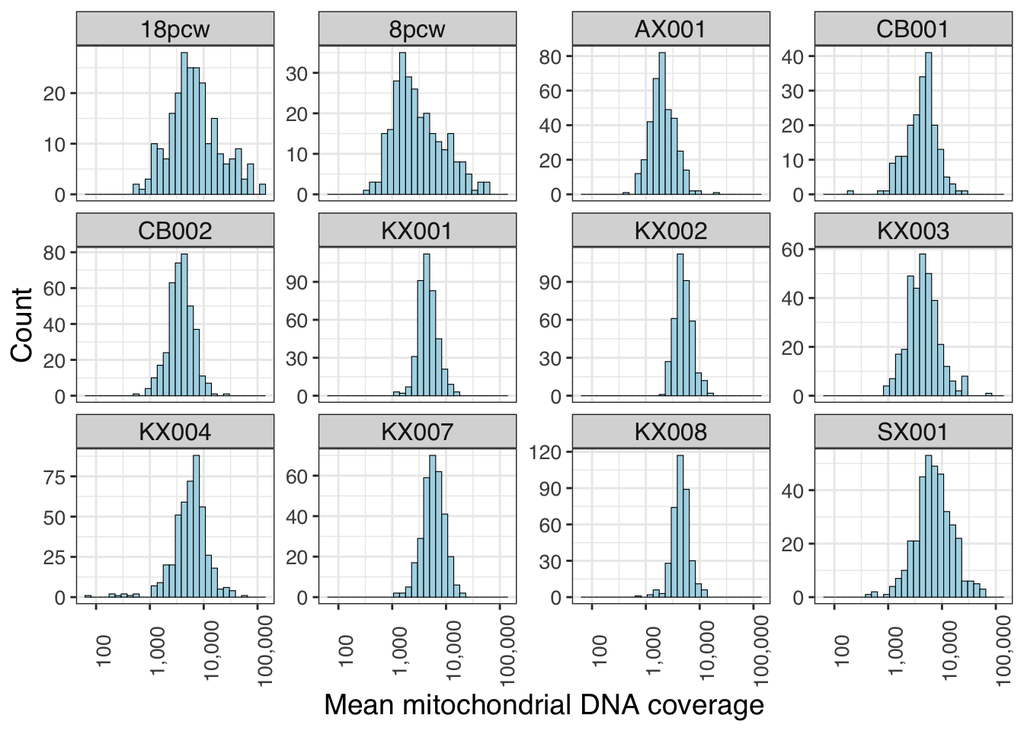

```r
#Generate the coverage histograms
coverage.plot<-mito_cn%>%
  dplyr::filter(Study%in%ref_df$Canapps.project & Sample%in% unlist(lapply(mito_data,function(list) list$tree$tip.label)))%>%
  ggplot(aes(x=bedtools_mtDNA_coverage))+
  geom_histogram(fill="lightblue",col="black",linewidth=0.2,bins=30)+
  scale_x_log10(labels=scales::label_comma())+
  facet_wrap(~exp_ID,scales = "free_y")+
  theme_bw()+
  my_markdown_theme+
  theme(axis.text.x = element_text(angle=90),strip.text.x = element_text(size = 12,margin = margin(1,0,1,0, "mm")))+
  labs(x="Mean mitochondrial DNA coverage",y="Count")
coverage.plot
```

```r
save_plot(filename=paste0(plots_dir,"Coverage_plot.pdf"),coverage.plot,width=4,height=3)
```

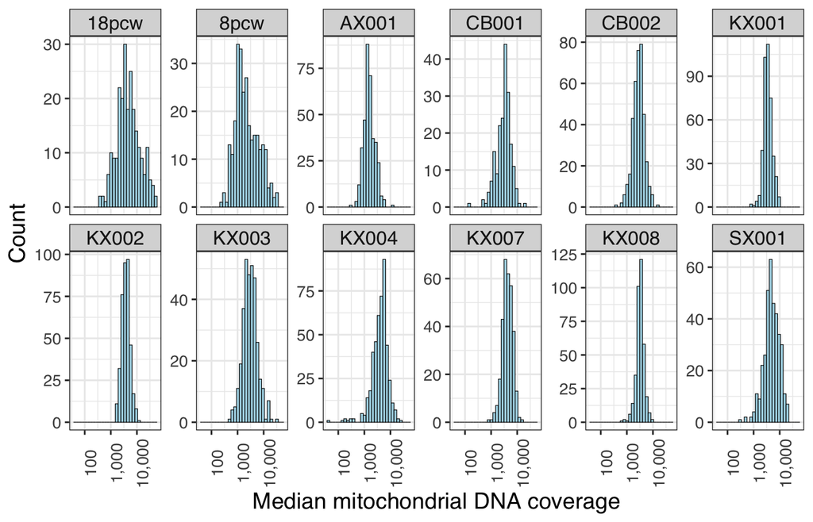

```r
median.coverage.plot<-mito_cn%>%
  dplyr::filter(Study%in%ref_df$Canapps.project & Sample%in% unlist(lapply(mito_data,function(list) list$tree$tip.label)))%>%
  ggplot(aes(x=pilup_median_mtDNA_coverage))+
  geom_histogram(fill="lightblue",col="black",linewidth=0.2,bins=30)+
  scale_x_log10(labels=scales::label_comma())+
  facet_wrap(~exp_ID,scales = "free_y",nrow=2)+
  theme_bw()+
  my_markdown_theme+
  theme(axis.text.x = element_text(angle=90),strip.text.x = element_text(size = 12,margin = margin(1,0,1,0, "mm")))+
  labs(x="Median mitochondrial DNA coverage",y="Count")
median.coverage.plot
```

```r
save_plot(filename=paste0(plots_dir,"Coverage_median_plot.pdf"),median.coverage.plot,width=7,height=2)
```

A ridges plot is perhaps better here to compare.

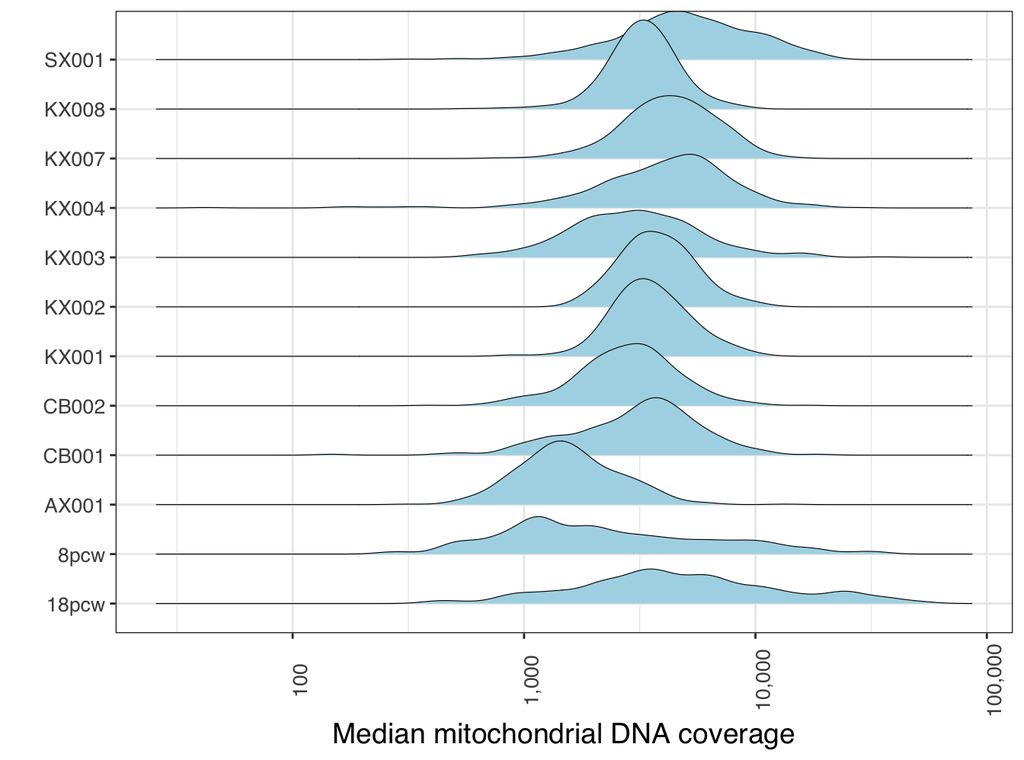

```r
median.coverage.ridges.plot<-mito_cn%>%
  dplyr::filter(Study%in%ref_df$Canapps.project & Sample%in% unlist(lapply(mito_data,function(list) list$tree$tip.label)))%>%
  ggplot(aes(x=pilup_median_mtDNA_coverage,y=exp_ID))+
  ggridges::geom_density_ridges(linewidth=0.2,fill="lightblue")+
  scale_x_log10(labels=scales::label_comma())+
  theme_bw()+
  my_markdown_theme+
  theme(axis.text.x = element_text(angle=90),strip.text.x = element_text(size = 12,margin = margin(1,0,1,0, "mm")))+
  labs(x="Median mitochondrial DNA coverage",y="")
median.coverage.ridges.plot
```

```r
save_plot(filename=paste0(plots_dir,"median.coverage.ridges.plot.pdf"),median.coverage.ridges.plot,width=3.3,height=2.5)
```

Uniformity across the mtDNA genome is also a key marker of coverage quality. We use a very stringent marker of uniformity - the proportion of genome with >80% of the mean.

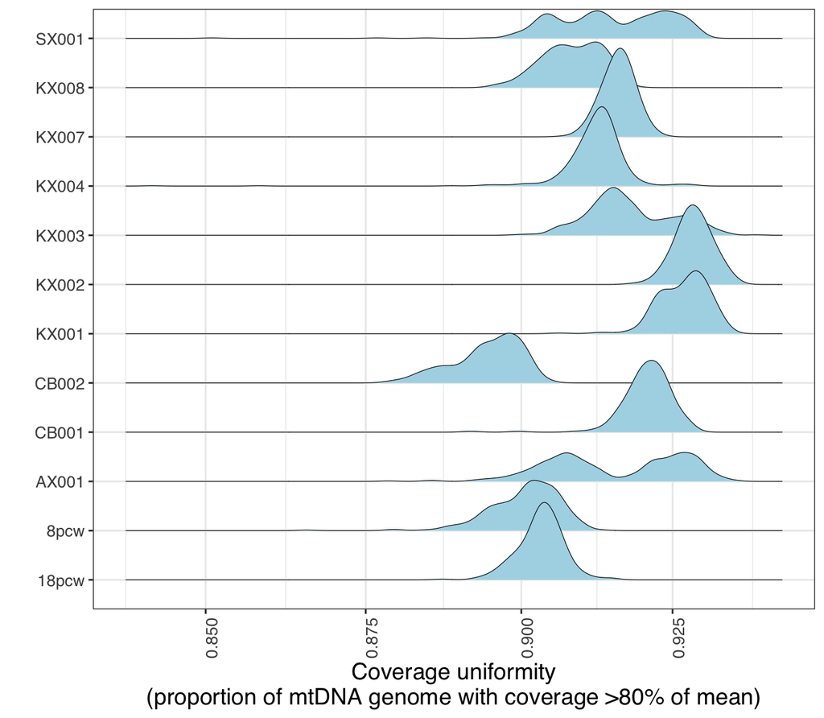

```r
uniformity_ridges.plot<-mito_cn%>%
  dplyr::filter(Study%in%ref_df$Canapps.project & Sample%in% unlist(lapply(mito_data,function(list) list$tree$tip.label)))%>%
  ggplot(aes(x=perc_over0.8,y=exp_ID))+
  ggridges::geom_density_ridges(linewidth=0.2,fill="lightblue")+
  scale_x_log10()+
  theme_bw()+
  my_markdown_theme+
  theme(axis.text.x = element_text(angle=90),strip.text.x = element_text(size = 12,margin = margin(1,0,1,0, "mm")))+
  labs(x="Coverage uniformity\n(proportion of mtDNA genome with coverage >80% of mean)",y="")
uniformity_ridges.plot
```

```r
save_plot(filename=paste0(plots_dir,"Uniformity_perc80_ridges_plot.pdf"),uniformity_ridges.plot,width=3.3,height=2.5)
```

Print coverage summary statistics

```r
mito_cn%>%
  dplyr::filter(Study%in%ref_df$Canapps.project & Sample%in% unlist(lapply(mito_data,function(list) list$tree$tip.label)))%>%
  group_by(exp_ID)%>%
  summarise(samples=n(),mean_mtDNA_coverage=mean(bedtools_mtDNA_coverage),Under_1000X=sum(bedtools_mtDNA_coverage<1000))
```

```
## # A tibble: 12 × 4
##    exp_ID samples mean_mtDNA_coverage Under_1000X
##    <chr>    <int>               <dbl>       <int>
##  1 18pcw      234              12661.           6
##  2 8pcw       277               5845.          32
##  3 AX001      361               2403.          23
##  4 CB001      195               5030.           2
##  5 CB002      379               4304.           3
##  6 KX001      407               5028.           0
##  7 KX002      383               5367.           0
##  8 KX003      337               5694.           4
##  9 KX004      451               7041.           9
## 10 KX007      315               6391.           0
## 11 KX008      367               4732.           1
## 12 SX001      361               9580.           3
```

```r
mito_cn%>%
  dplyr::filter(Study%in%ref_df$Canapps.project & Sample%in% unlist(lapply(mito_data,function(list) list$tree$tip.label)))%>%
  summarise(mean_mtDNA_coverage=mean(bedtools_mtDNA_coverage))
```

```
##   mean_mtDNA_coverage
## 1            6015.523
```

## Mitochondrial DNA copy number

Get some basic MITOCHONDRIAL COPY NUMBER STATISTICS

```r
#Vector to convert the foetal cell type codes into basic 'HSC'/ 'Progenitor' types
convert_vec=c("HSC","HSC","HPC","HPC","HPC","HPC")
names(convert_vec)=c("H","HSC","C","M","HSPC","Progenitor")

mtDNA_by_pheno_and_ID_summary<-mito_cn%>%
  filter(!is.na(Phenotype) & Cell_type=="HSC")%>%
  group_by(exp_ID,Phenotype)%>%
  summarise(n=n(),
            mean_mtDNA_genomes=mean(bedtools_mtDNA_genomes),
            median_mtDNA_genomes=median(bedtools_mtDNA_genomes))
```

```
## `summarise()` has regrouped the output.
## ℹ Summaries were computed grouped by exp_ID and Phenotype.
## ℹ Output is grouped by exp_ID.
## ℹ Use `summarise(.groups = "drop_last")` to silence this message.
## ℹ Use `summarise(.by = c(exp_ID, Phenotype))` for per-operation grouping
##   (`?dplyr::dplyr_by`) instead.
```

```r
mtDNA_by_pheno_summary<-mito_cn%>%
  filter(!is.na(Phenotype) & Cell_type=="HSC")%>%
  group_by(Phenotype)%>%
  summarise(n=n(),
            mean_mtDNA_genomes=mean(bedtools_mtDNA_genomes),
            median_mtDNA_genomes=median(bedtools_mtDNA_genomes))
```

Review the average copy number of colonies with different phenotypes relative to the average copy number of erythroid colonies

```r
pheno_levels=c("Ery","EryMy","Gran","MyGran","MyMono","Mono","NKMy")
mtDNA_by_pheno_and_ID_summary%>%
  dplyr::select(-n)%>%
  pivot_wider(id_cols=c("exp_ID"),names_from="Phenotype",values_from="median_mtDNA_genomes")%>%
  mutate(across(all_of(pheno_levels),.fns = function(x) x/Ery))
```

```
## # A tibble: 10 × 8
## # Groups:   exp_ID [10]
##    exp_ID   Ery EryMy   Gran  Mono MyGran MyMono  NKMy
##    <chr>  <dbl> <dbl>  <dbl> <dbl>  <dbl>  <dbl> <dbl>
##  1 AX001      1  1.21  0.903  2.15  1.07   1.29  NA
##  2 CB001      1  2.69  5.53   3.55  1.45   2.42   4.17
##  3 CB002      1  1.79  3.20   2.73  2.15   2.53   3.11
##  4 KX001      1  2.35 NA      3.15  2.37   2.92   2.38
##  5 KX002     NA NA    NA     NA    NA     NA     NA
##  6 KX003      1  2.27 NA     NA     2.02   2.09  NA
##  7 KX004      1  2.11 NA      3.51  2.59   2.79  NA
##  8 KX007      1  1.62  1.54   2.85  1.89   2.88   2.59
##  9 KX008      1  1.96  1.77   2.63  1.82   2.78  NA
## 10 SX001      1  1.36  1.83  NA     0.585  0.545 NA
```

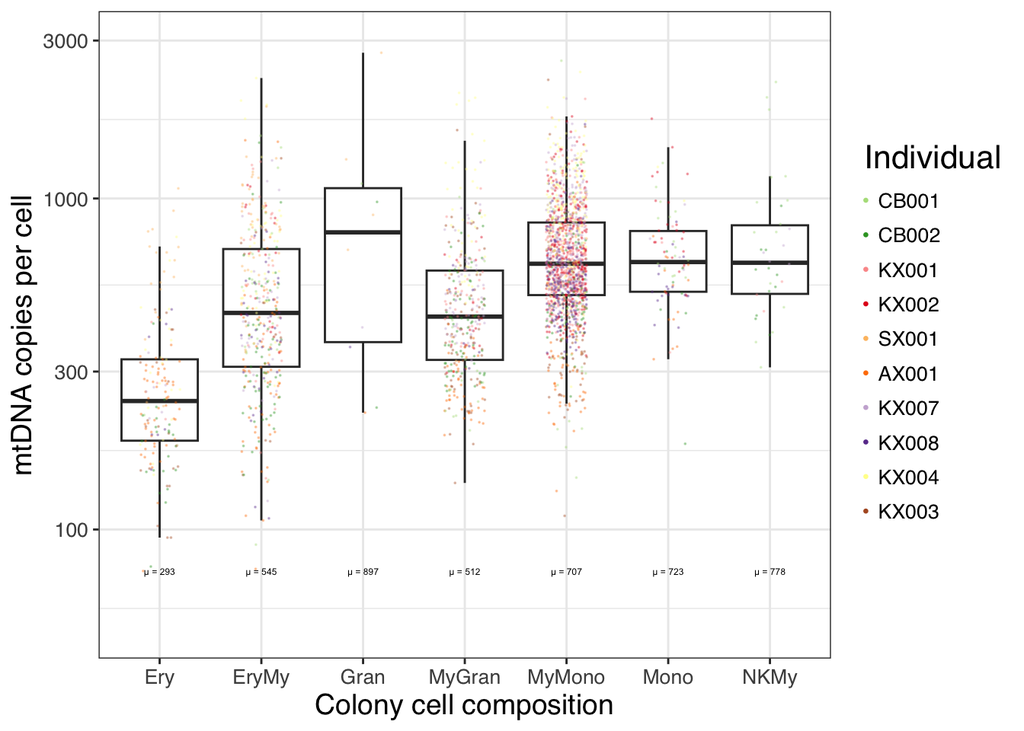

```r
mito_cn_by_pheno<-mito_cn%>%
  filter(!is.na(Phenotype) & Cell_type=="HSC")%>%
  dplyr::select(exp_ID,Sample,bedtools_mtDNA_genomes,Phenotype)%>%
  ggplot(aes(x=factor(Phenotype,levels=pheno_levels),y=bedtools_mtDNA_genomes))+
  geom_boxplot(outlier.shape = NA)+
  geom_jitter(aes(col=factor(exp_ID,levels=ref_df$Sample[order(ref_df$Age)])),width=0.2,height=0,alpha=0.3,size=0.025)+
  scale_y_log10(limits=c(50,3000))+
  theme_bw()+
  scale_color_manual(values = Individual_cols[-c(1,2)])+
  guides(col=guide_legend(override.aes = list(alpha=1,size=0.5)))+
  labs(x="Colony cell composition",y="mtDNA copies per cell",col="Individual")+
  geom_text(data=mtDNA_by_pheno_summary,aes(label=paste0("µ = ",round(mean_mtDNA_genomes)),x=Phenotype,y=75),size=1.6,inherit.aes = F)+
  my_markdown_theme+
  theme(#axis.text.x = element_text(angle=90),
        strip.text.x = element_text(size = 14,margin = margin(t=1,r=0,b=1,l=0,unit="mm")),
        legend.key.size = unit(0,"mm"),
        legend.position="right")
mito_cn_by_pheno
```

```r
save_plot(filename=paste0(plots_dir,"mito_cn_by_pheno.pdf"),mito_cn_by_pheno,width=4,height=2)
```

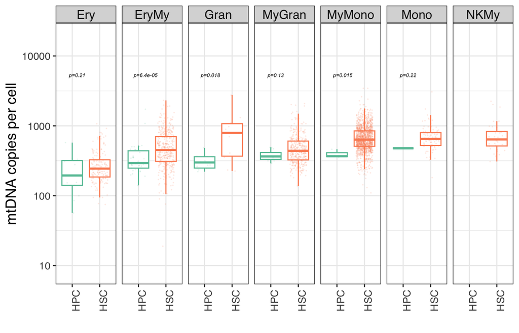

```r
mito_cn_by_pheno_all_HSCprog<-mito_cn%>%
  filter(!is.na(Phenotype))%>%
  mutate(Cell_type=ifelse(Cell_type=="Progenitor","HPC",Cell_type))%>%
  dplyr::select(exp_ID,Cell_type,Sample,bedtools_mtDNA_genomes,Phenotype)%>%
  ggplot(aes(x=factor(Cell_type),y=bedtools_mtDNA_genomes,col=factor(Cell_type)))+
  geom_boxplot(outlier.shape = NA)+
  geom_jitter(width=0.3,height=0,alpha=0.1,size=0.1)+
  ggpubr::stat_compare_means(aes(label = paste0("p=", ..p.format..)), label.x=1.0,label.y=3.7,method="wilcox.test",size=1.8,fontface="italic")+
  scale_color_brewer(palette = "Set2")+
  scale_y_log10(limits=c(8,20000),breaks=c(10,100,1000,10000))+
  facet_grid(~factor(Phenotype,levels=pheno_levels))+
  theme_bw()+
  labs(x="",col="Founder cell\nphenotype",y="mtDNA copies per cell")+
  my_markdown_theme+
  theme(axis.text.x = element_text(angle=90),strip.text.x = element_text(size = 12,margin = margin(t=1,r=0,b=1,l=0,unit="mm")),legend.position="none",legend.title = element_text(size = 14))
mito_cn_by_pheno_all_HSCprog
```

```r
save_plot(filename=paste0(plots_dir,"mito_cn_by_pheno_HSCprog.pdf"),mito_cn_by_pheno_all_HSCprog,width=4,height=2)

#Generate the table of average CN by cell type - these values are overlaid onto the above plot
mito_cn%>%
  filter(!is.na(Phenotype))%>%
  mutate(Cell_type=ifelse(Cell_type=="Progenitor","HPC",Cell_type))%>%
  dplyr::select(exp_ID,Cell_type,Sample,bedtools_mtDNA_genomes,Phenotype)%>%
  group_by(Cell_type,Phenotype)%>%
  summarise(median_CN=median(bedtools_mtDNA_genomes))
```

```
## `summarise()` has regrouped the output.
## ℹ Summaries were computed grouped by Cell_type and Phenotype.
## ℹ Output is grouped by Cell_type.
## ℹ Use `summarise(.groups = "drop_last")` to silence this message.
## ℹ Use `summarise(.by = c(Cell_type, Phenotype))` for per-operation grouping
##   (`?dplyr::dplyr_by`) instead.
```

```
## # A tibble: 13 × 3
## # Groups:   Cell_type [2]
##    Cell_type Phenotype median_CN
##    <chr>     <chr>         <dbl>
##  1 HPC       Ery            195.
##  2 HPC       EryMy          294.
##  3 HPC       Gran           299.
##  4 HPC       Mono           477.
##  5 HPC       MyGran         365.
##  6 HPC       MyMono         367.
##  7 HSC       Ery            244.
##  8 HSC       EryMy          451.
##  9 HSC       Gran           796.
## 10 HSC       Mono           650.
## 11 HSC       MyGran         440.
## 12 HSC       MyMono         636.
## 13 HSC       NKMy           640.
```

Generate a plot of mtDNA copy number across samples, grouped by individual.

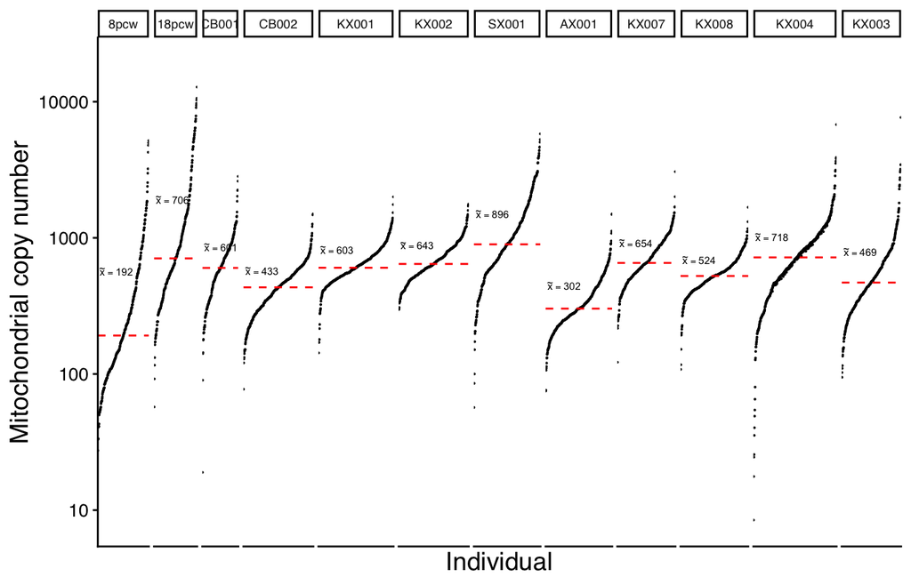

```r
Individual_means_df<-mito_cn%>%
  mutate(Cell_type=convert_vec[Cell_type])%>%
  filter(Sample%in%unlist(lapply(mito_data,function(list) list$tree$tip.label))&
           !is.na(bedtools_mtDNA_genomes)&
           #Cell_type=="HSC"&
           !is.na(exp_ID))%>%
  group_by(exp_ID)%>%
  summarise(mean=mean(bedtools_mtDNA_genomes,na.rm=T),median=median(bedtools_mtDNA_genomes,na.rm=T),sd=sd(bedtools_mtDNA_genomes,na.rm=T),IQR_lower=quantile(bedtools_mtDNA_genomes,0.25),IQR_upper=quantile(bedtools_mtDNA_genomes,0.75))
Individual_means_df$exp_ID<-factor(Individual_means_df$exp_ID,levels=ref_df$Sample[order(ref_df$Age)])

studies_to_include=ref_df$Canapps.project
mtDNA.copy.number.logscale<-mito_cn%>%
  mutate(Cell_type=convert_vec[Cell_type])%>%
  filter(Sample%in%unlist(lapply(mito_data,function(list) list$tree$tip.label))&
           !is.na(bedtools_mtDNA_genomes)&
           !is.na(exp_ID))%>%
  ggplot(aes(x=factor(Sample,levels=mito_cn%>%dplyr::filter(Study%in%studies_to_include)%>%arrange(bedtools_mtDNA_genomes)%>%pull(Sample)%>%unique()),
             y=bedtools_mtDNA_genomes))+
  geom_point(size = 0.7, stroke = 0, shape = 16,col="black")+
  scale_y_log10(limits=c(8,20000),breaks=c(10,100,1000,10000))+
  theme_classic()+
  facet_grid(cols=vars(factor(exp_ID,levels = ref_df$Sample[order(ref_df$Age)])),scales="free",space = "free")+
  geom_hline(aes(yintercept=median),linetype=2,data=Individual_means_df,col="red",linewidth=0.5)+
  geom_text(aes(x=100,y=mean,label=paste0("tilde(x) == ",round(median))),nudge_y=+0.1,size=2,data=Individual_means_df,parse=T,inherit.aes = F)+
  labs(x="Individual",y="Mitochondrial copy number")+
  my_markdown_theme+
  theme(axis.text.x = element_blank(),
        axis.ticks.x = element_blank(),
        legend.title = element_text(size = 16),
        legend.key.height = unit(2,"mm"),
        strip.text.x = element_text(size = 7), #narrow space="free" panels truncate larger strip labels
        panel.spacing.x=unit(1, "mm"))+
  guides(colour = guide_legend(override.aes = list(size=2)))

mtDNA.copy.number.logscale
```

```r
save_plot(filename = paste0(plots_dir,"mtDNA.copy.number.logscale.pdf"),plot=mtDNA.copy.number.logscale,height=2,width=7)
```

Generate the same plot, but now colour points by the colony phenotype. This is slightly difficult to interpret due to the multitude of colours!

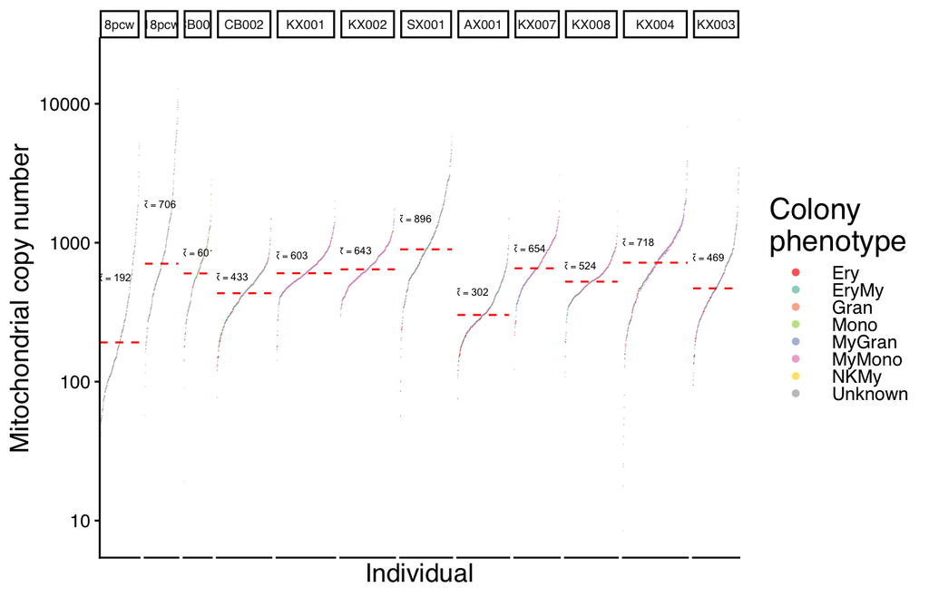

```r
phenotype_cols=c("red",RColorBrewer::brewer.pal(n=length(pheno_levels)-1,name = "Set2"),"darkgray") #Make the erythroid red, and 'unknown' dark grey
names(phenotype_cols)<-c(pheno_levels,"Unknown")
mtDNA.copy.number.logscale.by.phenotype<-mito_cn%>%
  mutate(Cell_type=convert_vec[Cell_type])%>%
  filter(Sample%in%unlist(lapply(mito_data,function(list) list$tree$tip.label))&
           !is.na(bedtools_mtDNA_genomes)&
           !is.na(exp_ID))%>%
  replace_na(replace=list(Phenotype="Unknown"))%>%
  ggplot(aes(x=factor(Sample,levels=mito_cn%>%dplyr::filter(Study%in%studies_to_include)%>%arrange(bedtools_mtDNA_genomes)%>%pull(Sample)%>%unique()),
             y=bedtools_mtDNA_genomes,
             col=Phenotype))+
  geom_point(size = 0.3, alpha=0.7,stroke = 0, shape = 16)+
  scale_y_log10(limits=c(8,20000),breaks=c(10,100,1000,10000))+
  scale_color_manual(values=phenotype_cols)+
  theme_classic()+
  facet_grid(cols=vars(factor(exp_ID,levels = ref_df$Sample[order(ref_df$Age)])),scales="free",space = "free")+
  geom_hline(aes(yintercept=median),linetype=2,data=Individual_means_df,col="red",linewidth=0.5)+
  geom_text(aes(x=100,y=mean,label=paste0("tilde(x) == ",round(median))),nudge_y=+0.1,size=2,data=Individual_means_df,parse=T,inherit.aes = F)+
  labs(x="Individual",y="Mitochondrial copy number",col="Colony\nphenotype")+
  my_markdown_theme+
  theme(axis.text.x = element_blank(),
        axis.ticks.x = element_blank(),
        legend.title = element_text(size = 16),
        legend.key.height = unit(2,"mm"),
        strip.text.x = element_text(size = 7), #narrow space="free" panels truncate larger strip labels
        panel.spacing.x=unit(1, "mm"))+
  guides(colour = guide_legend(override.aes = list(size=2)))

mtDNA.copy.number.logscale.by.phenotype
```

```r
save_plot(filename = paste0(plots_dir,"mtDNA.copy.number.logscale.by.phenotype.pdf"),plot=mtDNA.copy.number.logscale.by.phenotype,height=2,width=7)
```

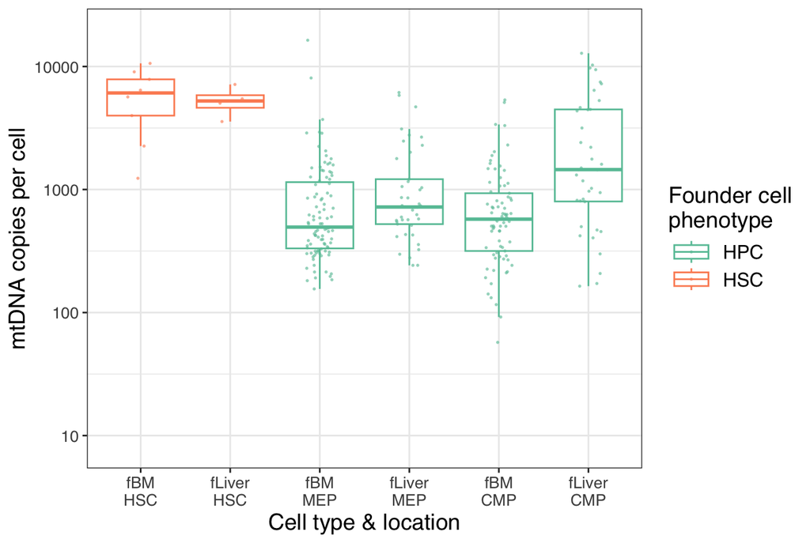

```r
#Look in more details at the 18 pcw copy number by cell type & location
convert_vec2=c("HSC","MEP","CMP"); names(convert_vec2)=c("H","M","C")
convert_vec3=c("fBM","fLiver");names(convert_vec3)<-c("F","L")
foetal_18pcw_by_cell_type_loc<-mito_cn%>%
  filter(exp_ID=="18pcw")%>%
  mutate(Cell_type2=convert_vec[Cell_type])%>%
  mutate(Cell_type=convert_vec2[Cell_type],Tissue=convert_vec3[gsub("1|2","",Tissue.y)])%>%
  mutate(Cell_type_loc=paste(Tissue,Cell_type,sep="\n"))%>%
  ggplot(aes(x=factor(Cell_type_loc,levels=apply(expand.grid(convert_vec3,convert_vec2),1,paste,collapse="\n")),
             y=bedtools_mtDNA_genomes,
             col=Cell_type2))+
  geom_boxplot(outlier.shape = NA)+
  geom_jitter(width=0.15,height=0,size=0.3,alpha=0.5)+
  scale_color_brewer(palette="Set2")+
  theme_bw()+
  my_markdown_theme+
  scale_y_log10(limits=c(8,20000),breaks=c(10,100,1000,10000))+
  theme(legend.title = element_text(size = 14),legend.text = element_text(size = 12))+
  labs(x="Cell type & location",y="mtDNA copies per cell",col="Founder cell\nphenotype")

foetal_18pcw_by_cell_type_loc
```

```r
save_plot(filename=paste0(plots_dir,"foetal_18pcw_by_cell_type_loc.pdf"),foetal_18pcw_by_cell_type_loc,width=3,height=2)
```

### Assess for a relationship between age and mtDNA copy number

Plot the median mitochondrial CN by age

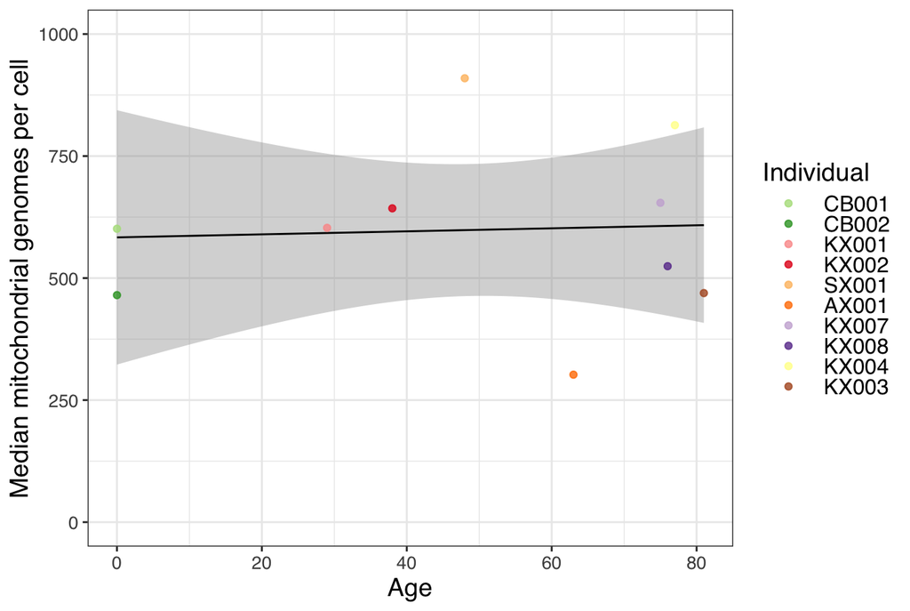

```r
median_mtDNA_CN_by_age<-mito_cn%>%
  filter(Sample%in%unlist(lapply(mito_data,function(list) list$tree$tip.label))&
           !is.na(bedtools_mtDNA_genomes)&
           !is.na(exp_ID)&
           Cell_type=="HSC")%>%
  group_by(exp_ID)%>%
  summarise(mean=mean(bedtools_mtDNA_genomes,na.rm=T),median=median(bedtools_mtDNA_genomes,na.rm=T),sd=sd(bedtools_mtDNA_genomes,na.rm=T))%>%
  left_join(ref_df,by=c("exp_ID"="Sample"))%>%
  ggplot(aes(x=Age,y=median,col=factor(exp_ID,levels=ref_df$Sample[order(ref_df$Age)])))+
  geom_smooth(aes(x=Age,y=median),method="lm",inherit.aes = F,col="black",linewidth=0.5)+
  geom_point(alpha=0.8)+
  scale_color_manual(values = Individual_cols)+
  theme_bw()+
  scale_y_continuous(limits=c(0,1000))+
  labs(y="Median mitochondrial genomes per cell",col="Individual")+
  my_markdown_theme+
  theme(legend.key.height = unit(3,"mm"),legend.title=element_text(size = 14),legend.text=element_text(size = 12))
median_mtDNA_CN_by_age
```

```r
save_plot(filename = paste0(plots_dir,"median_mtDNA_CN_by_age.pdf"),plot = median_mtDNA_CN_by_age,width=3.5,height=2)
```

Now do a formal regression to confirm if there is any kind of significant relationship (although not evident visually).

```r
CN_by_age_summary<-mito_cn%>%
  filter(Sample%in%unlist(lapply(mito_data,function(list) list$tree$tip.label))&
           !is.na(bedtools_mtDNA_genomes)&
           !is.na(exp_ID)&
           Cell_type=="HSC")%>%
  group_by(exp_ID)%>%
  summarise(mean=mean(bedtools_mtDNA_genomes,na.rm=T),median=median(bedtools_mtDNA_genomes,na.rm=T),sd=sd(bedtools_mtDNA_genomes,na.rm=T))%>%
  left_join(ref_df,by=c("exp_ID"="Sample"))
lm.CN_by_age<-lm(median~Age,data=CN_by_age_summary)
summary(lm.CN_by_age)
```

```
##
## Call:
## lm(formula = median ~ Age, data = CN_by_age_summary)
##
## Residuals:
##     Min      1Q  Median      3Q     Max
## -300.75 -109.38   14.11   47.70  311.15
##
## Coefficients:
##             Estimate Std. Error t value Pr(>|t|)
## (Intercept) 583.4166   112.9981   5.163  0.00086 ***
## Age           0.3093     1.9837   0.156  0.87994
## ---
## Signif. codes:  0 '***' 0.001 '**' 0.01 '*' 0.05 '.' 0.1 ' ' 1
##
## Residual standard error: 185.4 on 8 degrees of freedom
## Multiple R-squared:  0.00303,    Adjusted R-squared:  -0.1216
## F-statistic: 0.02432 on 1 and 8 DF,  p-value: 0.8799
```

```r
confint(lm.CN_by_age)
```

```
##                  2.5 %     97.5 %
## (Intercept) 322.842531 843.990707
## Age          -4.265031   4.883694
```

### Test mitochondrial copy number for phylogenetic signal

How heritable is mitochondrial copy number? One way to look at this is to look for “phylogenetic signal”. This looks at whether the variation in copy number is explained by their lineage relationships, as defined by the phylogeny.

```
## scale= 10
```

```
## scale= 10
```

```
## scale= 100
```

```
## scale= 100
```

```
## scale= 200
```

```
## scale= 200
```

```
## scale= 200
```

```
## scale= 200
```

```
## scale= 100
```

```
## scale= 200
```

```
## scale= 5
```

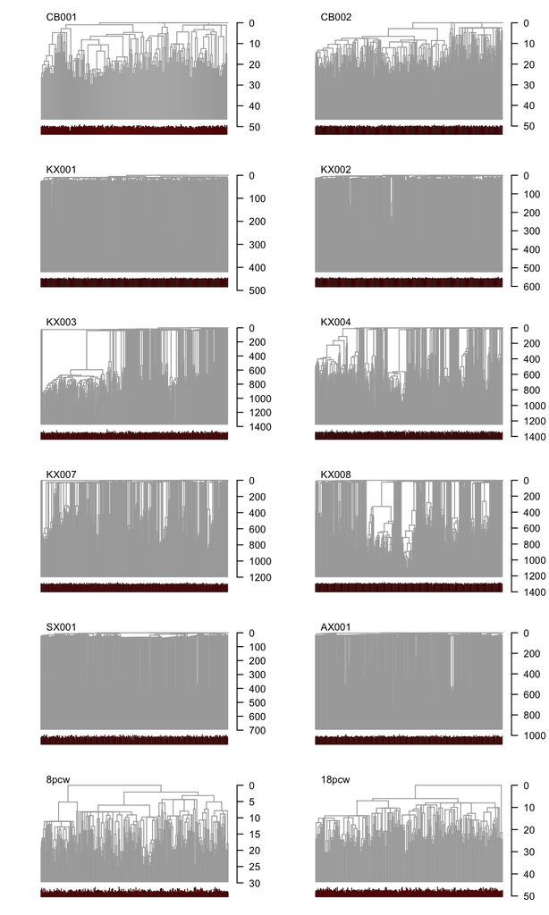

```
## scale= 10
```

[output not shown]

[output cut: 76 more lines]

[output not shown]

```r
if(!file.exists(paste0(root_dir,"/data/mito_cn_phylo.Rds"))) {
  mito_cn_phylo<-lapply(mito_data,function(list) {
    tree.no.ancestral=drop.tip(list$tree.ultra,"Ancestral")
    mito_cn_tree<-sapply(tree.no.ancestral$tip.label,function(sampleID) mito_cn%>%filter(Sample==sampleID&Study%in%studies_to_include)%>%slice_head(n=1)%>%pull(bedtools_mtDNA_genomes))
    tree.4d<-phylobase::phylo4d(tree.no.ancestral,tip.data=mito_cn_tree[tree.no.ancestral$tip.label])
    barplot.phylo4d(tree.4d)
    res<-phyloSignal(tree.4d)
    mut.crlg <- phyloCorrelogram(tree.4d)
    return(list(mito_cn=mito_cn_tree,tree4d=tree.4d,phyloSignal_res=res,phyloCor_res=mut.crlg))
  })
  saveRDS(mito_cn_phylo,file=paste0(root_dir,"/data/mito_cn_phylo.Rds"))
} else {
  mito_cn_phylo<-readRDS(paste0(root_dir,"/data/mito_cn_phylo.Rds"))
}

#Plot the mitochondrial copy number onto the trees (given the broad variation - plot as the log value)
par(mfrow=c(6,2))
Map(list=mito_data,mito_cn_phy=mito_cn_phylo,exp_ID=names(mito_data),function(list,mito_cn_phy,exp_ID){
  tree=plot_tree(list$tree.ultra,bars = log(mito_cn_phy$mito_cn),title=exp_ID)
})
```

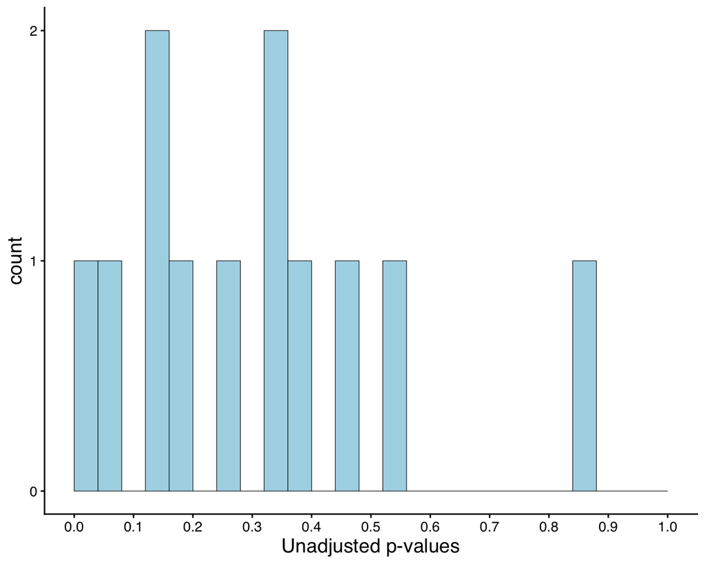

```r
#Histogram of p-values
sapply(mito_cn_phylo,function(dat) dat[[3]]$pvalue["dt","Cmean"])%>%
  as.data.frame()%>%
  tibble::rownames_to_column()%>%
  dplyr::rename("exp_ID"=1,"p-value"=2)%>%
  ggplot(aes(x=`p-value`))+
  geom_histogram(breaks=seq(0,1,0.04),fill="lightblue",col="black",linewidth=0.2)+
  scale_x_continuous(breaks=seq(0,1,0.1))+
  scale_y_continuous(breaks=seq(0,2,1))+
  theme_classic()+
  my_markdown_theme+
  labs(x="Unadjusted p-values")
```

# Mitochondrial DNA mutations

Generate a tidy dataframe of samples, mutations and VAFs (representing the heteroplasmy in the cell population).

```r
mutCN_cutoff=25 #If the mitochondrial copy number is over 25, retain mutation even if is in the "CN correlating muts" list
df_tidy<-dplyr::bind_rows(Map(list=mito_data,exp_ID=names(mito_data),function(list,exp_ID) {
  if(is.null(list)){stop(return(NULL))}
  CN_correlating_mut_removal_mat=list$matrices$implied_mutCN>mutCN_cutoff|(matrix((!rownames(list$matrices$vaf)%in%CN_correlating_muts),ncol=1)%*%matrix(rep(1,ncol(list$matrices$vaf)),nrow=1))
  implied_mut_CN_tidy<-list$matrices$implied_mutCN%>%
    as.data.frame()%>%
    tibble::rownames_to_column(var="mut_ref")%>%
    dplyr::select(-global)%>%
    tidyr::gather(key="Sample",value="implied_mut_CN",-mut_ref)

  #This now only includes cells where the ML_sig is N1
  df_tidy<-(list$matrices$vaf*list$matrices$SW*(list$matrices$ML_Sig=="N1")*CN_correlating_mut_removal_mat)%>%
    as.data.frame()%>%
    tibble::rownames_to_column(var="mut_ref")%>%
    mutate(rho_val=list$rho_vals)%>%
    dplyr::select(-global)%>%
    tidyr::gather(key="Sample",value="vaf",-mut_ref,-rho_val)

  comb_tidy<-left_join(df_tidy,implied_mut_CN_tidy,by=c("Sample","mut_ref"))%>%
    dplyr::filter(!grepl("DEL|INS",mut_ref) & !mut_ref%in%exclude_muts)%>% #Exclude indels, and the 'black listed' mutations
    dplyr::filter(vaf>0)%>%
    mutate(exp_ID=exp_ID)
  return(comb_tidy)
  }))

#Filter the CN-correlating mutations - due to mis-mapping of nuclear reads.
#There may be some genuine mutations at these sites, in which case the implied mutation copy number will be much higher than ~2 (here an arbitrary threshold of 8 is applied)
df_tidy<-df_tidy%>%
  left_join(mito_cn%>%mutate(exp_ID=gsub("8pcw","8 pcw",exp_ID)))%>%
  mutate(implied_mut_CN=vaf*bedtools_mtDNA_genomes)%>%
  dplyr::filter(!(mut_ref%in%CN_correlating_muts & implied_mut_CN<=mutCN_cutoff))
head(df_tidy)
```

```
##        mut_ref      rho_val    Sample         vaf implied_mut_CN exp_ID
## 1 MT_16086_T_C 8.912509e-02 PD40315aa 0.029706790      14.075019  CB001
## 2   MT_512_A_C 8.912509e-05 PD40315aa 0.009090909       4.307255  CB001
## 3 MT_13102_G_A 2.511886e-04 PD40315ay 0.003750721       3.990711  CB001
## 4 MT_16086_T_C 8.912509e-02 PD40315ay 0.053130930      56.530505  CB001
## 5 MT_16086_T_C 8.912509e-02 PD40315fv 0.022897084      10.933098  CB001
## 6 MT_16086_T_C 8.912509e-02 PD40315ii 0.080225447     103.252712  CB001
##      Tissue.x Study     SeqX Normal pileup_mtDNA_coverage pileup_mtDNA_genomes
## 1 blood_emily  2084 11.64515                     2413.129             414.4437
## 2 blood_emily  2084 11.64515                     2413.129             414.4437
## 3 blood_emily  2084 14.60772                     6301.177             862.7186
## 4 blood_emily  2084 14.60772                     6301.177             862.7186
## 5 blood_emily  2084 18.60518                     3831.491             411.8735
## 6 blood_emily  2084 15.53892                     7736.857             995.8037
##   bedtools_autosome_coverage bedtools_chr1_coverage bedtools_chr2_coverage
```

[output cut: 111 more lines]

### Print headline statistics

Print basic stats of total mutation numbers called

```r
vaf_cut_off<-0
rho_cut_off<-0
sum(unlist(lapply(mito_data,function(list) {
  if(is.null(list)){stop(return(NULL))}
  vaf.filt<-(list$matrices$vaf*list$matrices$SW)[!grepl("DEL|INS",rownames(list$matrices$vaf))&
                                                   list$rho_vals>rho_cut_off&
                                                   !rownames(list$matrices$vaf)%in%exclude_muts,]
  total_pos=rowSums(vaf.filt>0,na.rm = T)
  return(sum(total_pos>0,na.rm=T))
})))
```

```
## [1] 30179
```

Total number of SNVs identified by shearwater - once CN correlating muts excluded

```r
sum(unlist(lapply(mito_data,function(list) {
  if(is.null(list)){stop(return(NULL))}
  CN_correlating_mut_removal_mat=list$matrices$implied_mutCN>mutCN_cutoff|(matrix((!rownames(list$matrices$vaf)%in%CN_correlating_muts),ncol=1)%*%matrix(rep(1,ncol(list$matrices$vaf)),nrow=1))
  vaf.filt<-(list$matrices$vaf*list$matrices$SW*CN_correlating_mut_removal_mat)[!grepl("DEL|INS",rownames(list$matrices$vaf))&
                                                                                  list$rho_vals>rho_cut_off&
                                                                                  !rownames(list$matrices$vaf)%in%exclude_muts,]
  total_pos=rowSums(vaf.filt>0,na.rm = T)
  return(sum(total_pos>0,na.rm=T))
})))
```

```
## [1] 28963
```

Total number of SNVs identified by shearwater - once CN correlating muts excluded and only N1 muts included

```r
sum(unlist(lapply(mito_data,function(list) {
  if(is.null(list)){stop(return(NULL))}
  CN_correlating_mut_removal_mat=list$matrices$implied_mutCN>mutCN_cutoff|(matrix((!rownames(list$matrices$vaf)%in%CN_correlating_muts),ncol=1)%*%matrix(rep(1,ncol(list$matrices$vaf)),nrow=1))
  vaf.filt<-(list$matrices$vaf*list$matrices$SW*(list$matrices$ML_Sig=="N1")*CN_correlating_mut_removal_mat)[!grepl("DEL|INS",rownames(list$matrices$vaf))&
                                                                                                               list$rho_vals>rho_cut_off&
                                                                                                               !rownames(list$matrices$vaf)%in%exclude_muts,]
  total_pos=rowSums(vaf.filt>0,na.rm = T)
  return(sum(total_pos>0,na.rm=T))
})))
```

```
## [1] 9207
```

Generate a dataframe of mean number of unique mutations per cell. Though not particularly interesting.

```r
Individual_burden_means_df<-df_tidy%>%
  dplyr::filter(Sample!="global"&
                  #ML_Sig=="N1"&
                  !mut_ref%in%exclude_muts)%>%
  group_by(Sample)%>%
  dplyr::summarise(exp_ID=unique(exp_ID),n_mut=sum(vaf>vaf_cut_off))%>%
  tidyr::complete(Sample,fill=list(n_mut=0))%>%
  mutate(exp_ID=sapply(Sample,function(SampleID) {mito_cn$exp_ID[mito_cn$Sample==SampleID][1]}))%>%
  mutate(exp_ID=gsub("8 pcw","8pcw",exp_ID))%>%
  group_by(exp_ID)%>%
  summarise(mean=mean(n_mut))

head(Individual_burden_means_df)
```

```
## # A tibble: 6 × 2
##   exp_ID  mean
##   <chr>  <dbl>
## 1 18pcw   1.50
## 2 8pcw    1.51
## 3 AX001   3.48
## 4 CB001   2.14
## 5 CB002   2.36
## 6 KX001   2.90
```

Generate Fig. 1 This shows what proportion of samples have at least one mutation above the threshold value on the x-axis.

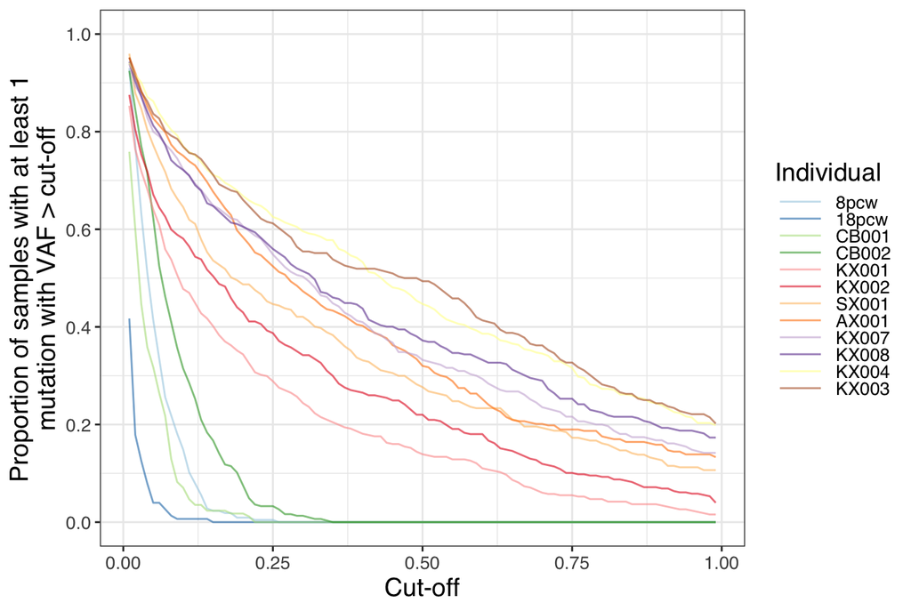

```r
#Cycle through the different thresholds (from 0.01 to 0.99) and see how many mutations are above that cut-off in each sample.
#Then group by the different individuals and look at the proportion of samples with at >0 mutations at that cutoff.

samples_with_mut_df<-dplyr::bind_rows(lapply(seq(0.01,0.99,0.01),function(cut_off) {
  cut_off_df<-df_tidy%>%
    dplyr::filter(Sample!="global"&
                    #ML_Sig=="N1"&
                    !mut_ref%in%exclude_muts)%>%
    group_by(Sample)%>%
    dplyr::summarise(n_mut=sum(vaf>cut_off))%>%
    tidyr::complete(Sample,fill=list(n_mut=0))%>%
    mutate(exp_ID=sapply(Sample,function(SampleID) {mito_cn$exp_ID[mito_cn$Sample==SampleID][1]}))%>%
    group_by(exp_ID)%>%
    dplyr::summarise(mean=mean(n_mut),n_with_mut=sum(n_mut>0),n_samp=n())%>%
    mutate(prop_with_mut=n_with_mut/n_samp,cut_off=cut_off)
  return(cut_off_df)
}))

prop.of.samples.with.mut<-samples_with_mut_df%>%
  dplyr::mutate(exp_ID=gsub("8 pcw","8pcw",exp_ID))%>%
  ggplot(aes(x=cut_off,y=prop_with_mut,col=factor(exp_ID,levels = ref_df$Sample[order(ref_df$Age)])))+
  #geom_point()+
  geom_line(alpha=0.6)+
  theme_bw()+
  scale_y_continuous(limits=c(0,1),breaks=seq(0,1,0.2))+
  scale_color_brewer(palette="Paired")+
  labs(x="Cut-off",
       y=str_wrap("Proportion of samples with at least 1 mutation with VAF > cut-off",width=40),
       col="Individual")+
  my_markdown_theme+
  theme(legend.key.height = unit(3,"mm"),legend.title = element_text(size = 14))

prop.of.samples.with.mut
```

```r
save_plot(filename=paste0(plots_dir,"Sample_proportions_with_mut.pdf"),prop.of.samples.with.mut,width=3,height=2)
```

### Assess burdens using the sum of VAF measure

A good measure of the overall mutation burden is the “sum of VAF”. For example, if this is 1, it means that - on average - each mitochondrial genome has one mutation.

```r
sum_of_vaf_df<-Map(list=mito_data,Exp_ID=names(mito_data),function(list,Exp_ID){
  #sum the vaf of mutations that:
  #(1) Pass shearwater,
  #(2) are most likely signature N1 (the real mutatation signature),
  #(3) are not indels, specific artefacts or 'copy number correlating mutations' (i.e. most likely artefacts from mismapping of nuclear DNA or low-level contamination)
  CN_correlating_mut_removal_mat=list$matrices$implied_mutCN>mutCN_cutoff|(matrix((!rownames(list$matrices$vaf)%in%CN_correlating_muts),ncol=1)%*%matrix(rep(1,ncol(list$matrices$vaf)),nrow=1))
  df<-as.data.frame(colSums((list$matrices$vaf*list$matrices$SW*(list$matrices$ML_Sig=="N1")*(CN_correlating_mut_removal_mat))[!grepl("DEL|INS",rownames(list$matrices$vaf))&
                                                                                                !rownames(list$matrices$vaf)%in%exclude_muts,],na.rm = T))%>%
    tibble::rownames_to_column(var="Sample")%>%
    mutate(exp_ID=Exp_ID)%>%
    dplyr::rename(sum_of_vaf=2)%>%
    dplyr::filter(Sample!="global")
  return(df)
})%>%
  dplyr::bind_rows()%>%
  left_join(mito_cn%>%dplyr::select(Sample,Cell_type,Phenotype),by="Sample")%>%
  dplyr::mutate(Cell_type=convert_vec[Cell_type])

sum_of_vaf_summary<-sum_of_vaf_df%>%
  mutate(exp_ID=gsub("8 pcw","8pcw",exp_ID))%>%
  group_by(exp_ID)%>%
  summarise(mean=mean(sum_of_vaf,na.rm=T),median=median(sum_of_vaf,na.rm = T))

head(sum_of_vaf_summary)
```

```
## # A tibble: 6 × 3
##   exp_ID   mean  median
##   <chr>   <dbl>   <dbl>
## 1 18pcw  0.0118 0.00497
## 2 8pcw   0.0493 0.0337
## 3 AX001  0.576  0.389
## 4 CB001  0.0472 0.0271
## 5 CB002  0.0945 0.0702
## 6 KX001  0.267  0.107
```

Look at the relationship between mean sum of vaf per cell, and the age of the individual. This has a clear linear relationship.

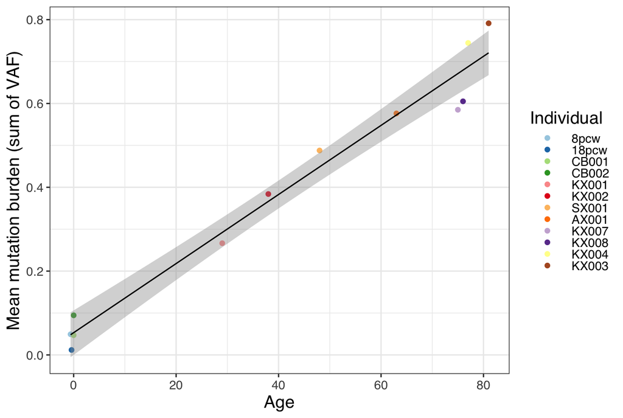

```r
mean_sum_of_vaf_by_age<-sum_of_vaf_summary%>%
  left_join(ref_df,by=c("exp_ID"="Sample"))%>%
  ggplot(aes(x=Age,y=mean,col=factor(exp_ID,levels = ref_df$Sample[order(ref_df$Age)])))+
  geom_point()+
  theme_bw()+
  scale_color_brewer(palette="Paired")+
  labs(col="Individual",y="Mean mutation burden (sum of VAF)")+
  geom_smooth(aes(x=Age,y=mean),col="black",linewidth=0.5,method="lm",inherit.aes = F)+
  my_markdown_theme+
  theme(legend.key.height = unit(3,"mm"),legend.title=element_text(size = 14),legend.text=element_text(size = 10))

mean_sum_of_vaf_by_age
```

```r
save_plot(filename=paste0(plots_dir,"mean_sum_of_vaf_by_age.pdf"),plot=mean_sum_of_vaf_by_age,height=2,width=3)
```

```r
lm.mean_mutburden_by_age=lm(mean~Age,data=sum_of_vaf_summary%>%
                              left_join(ref_df,by=c("exp_ID"="Sample")))
summary(lm.mean_mutburden_by_age)$coefficients
```

```
##                Estimate  Std. Error   t value     Pr(>|t|)
## (Intercept) 0.053104067 0.023854836  2.226134 5.017021e-02
## Age         0.008242562 0.000458736 17.967986 6.100654e-09
```

```r
summary(lm.mean_mutburden_by_age)$r.squared
```

```
## [1] 0.9699563
```

```r
confint(lm.mean_mutburden_by_age)
```

```
##                     2.5 %     97.5 %
## (Intercept) -4.781943e-05 0.10625595
## Age          7.220435e-03 0.00926469
```

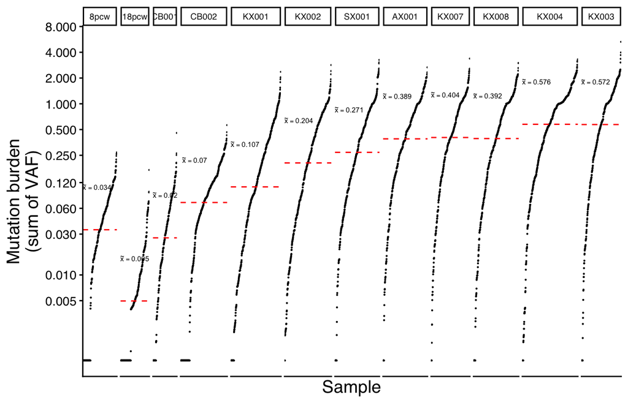

```r
sum_of_vaf_plot_log<-sum_of_vaf_df%>%
  mutate(exp_ID=gsub("8 pcw","8pcw",exp_ID))%>%
  mutate(sum_of_vaf=ifelse(sum_of_vaf==0,0.001,sum_of_vaf))%>%
  ggplot(aes(x=forcats::fct_reorder(Sample,sum_of_vaf),y=sum_of_vaf))+
  geom_point(size=0.1)+
  theme_classic()+
  my_markdown_theme+
  theme(axis.text.x=element_blank(),axis.ticks.x=element_blank(),strip.text.x = element_text(size = 7))+ #narrow space="free" panels truncate larger strip labels
  facet_grid(cols=vars(factor(exp_ID,levels=ref_df$Sample[order(ref_df$Age)])),scales = "free",space="free")+
  scale_y_log10(breaks=c(0.005,0.01,0.03,0.06,0.12,0.25,0.5,1,2,4,8))+
  geom_hline(aes(yintercept=median),linetype=2,data=sum_of_vaf_summary%>%mutate(median=ifelse(median==0,0.001,median)),col="red",linewidth=0.5)+
  geom_text(aes(x=0,y=median_pos,label=paste0("tilde(x) == ",round(median,3))),size=2,nudge_x=+115,nudge_y=+0.5,data=sum_of_vaf_summary%>%mutate(median_pos=ifelse(median==0,0.001,median)),parse=T)+
  labs(x="Sample",y="Mutation burden\n(sum of VAF)")+
  theme(panel.spacing.x=unit(1, "mm"))

sum_of_vaf_plot_log
```

```r
save_plot(filename = paste0(plots_dir,"sum_of_vaf_log.pdf"),plot=sum_of_vaf_plot_log,height=2,width=7)
```

Now coloured by cell type, as requested by the reviewer.

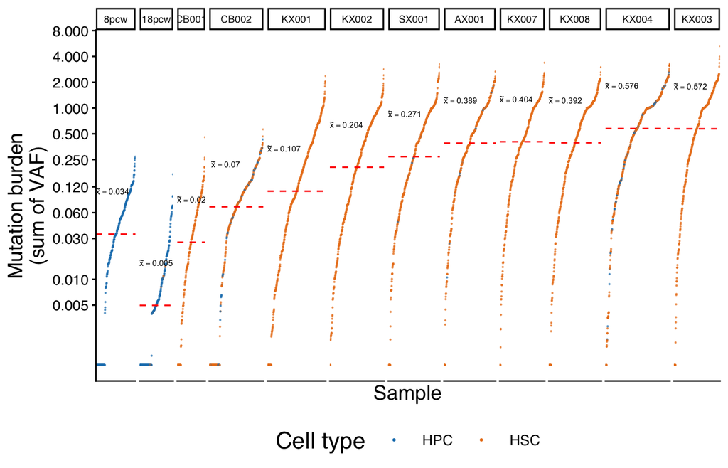

```r
sum_of_vaf_plot_log_by_celltype<-sum_of_vaf_df%>%
  mutate(exp_ID=gsub("8 pcw","8pcw",exp_ID))%>%
  mutate(sum_of_vaf=ifelse(sum_of_vaf==0,0.001,sum_of_vaf))%>%
  ggplot(aes(x=forcats::fct_reorder(Sample,sum_of_vaf),y=sum_of_vaf))+
  geom_point(aes(col=Cell_type),size=0.1,alpha=0.6)+
  scale_color_manual(values=c("#1a80bb", "#ea801c"))+
  theme_classic()+
  my_markdown_theme+
  theme(axis.text.x=element_blank(),axis.ticks.x=element_blank(),strip.text.x = element_text(size = 7))+ #narrow space="free" panels truncate larger strip labels
  facet_grid(cols=vars(factor(exp_ID,levels=ref_df$Sample[order(ref_df$Age)])),scales = "free",space="free")+
  scale_y_log10(breaks=c(0.005,0.01,0.03,0.06,0.12,0.25,0.5,1,2,4,8))+
  geom_hline(aes(yintercept=median),linetype=2,data=sum_of_vaf_summary%>%mutate(median=ifelse(median==0,0.001,median)),col="red",linewidth=0.5)+
  geom_text(aes(x=0,y=median_pos,label=paste0("tilde(x) == ",round(median,3))),size=2,nudge_x=+115,nudge_y=+0.5,data=sum_of_vaf_summary%>%mutate(median_pos=ifelse(median==0,0.001,median)),parse=T)+
  labs(x="Sample",y="Mutation burden\n(sum of VAF)",col="Cell type")+
  guides(color=guide_legend(override.aes = list(size=0.4,alpha=1)))+
  theme(panel.spacing.x=unit(1, "mm"),legend.position = "bottom")

sum_of_vaf_plot_log_by_celltype
```

```r
save_plot(filename = paste0(plots_dir,"sum_of_vaf_log_by_celltype.pdf"),plot=sum_of_vaf_plot_log_by_celltype,height=2.2,width=7)
```

Comparison of mutation burden by cell type (HSCs and progenitor cell types) - violin plot, with overlaid comparisons using the non-parametric Wilcoxon test. This does not show any significant difference.

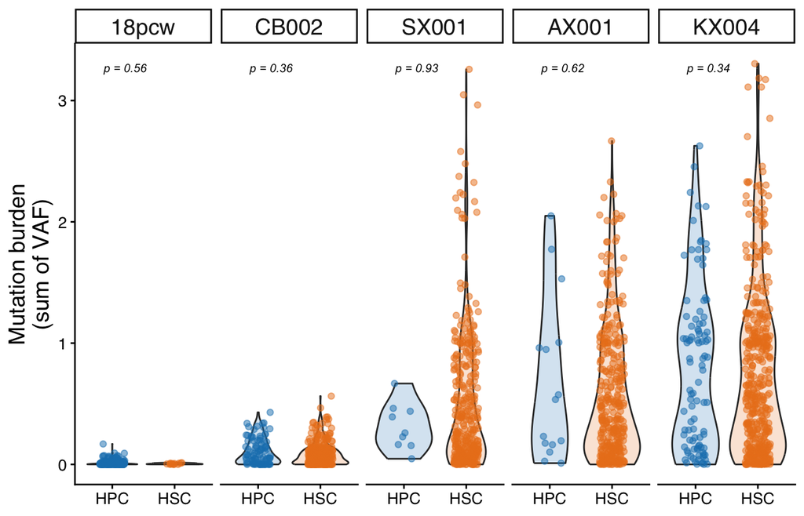

```r
individuals_with_both=c("18pcw","CB002","SX001","AX001","KX004")
sum_of_vaf_by_celltype<-sum_of_vaf_df%>%
  filter(exp_ID%in%individuals_with_both)%>%
  ggplot(aes(x=Cell_type,y=sum_of_vaf))+
  geom_violin(aes(fill=Cell_type),alpha=0.2)+
  scale_color_manual(values=c("#1a80bb", "#ea801c"))+
  scale_fill_manual(values=c("#1a80bb", "#ea801c"))+
  ggpubr::stat_compare_means(method = "wilcox.test",label = "p.format",fontface="italic",vjust = +1,size=2.6)+
  geom_jitter(aes(col=Cell_type),width=0.2,alpha=0.5)+
  facet_grid(cols=vars(factor(exp_ID,levels=ref_df$Sample[order(ref_df$Age)])),scales = "free",space="free")+
  theme_classic()+
  my_markdown_theme+
  labs(y="Mutation burden\n(sum of VAF)")+
  theme(axis.title.x=element_blank(),legend.position = "none")

sum_of_vaf_by_celltype
```

```r
save_plot(filename = paste0(plots_dir,"sum_of_vaf_by_celltype_comparison.pdf"),plot=sum_of_vaf_by_celltype,height=2.2,width=7)
```

## MUTATIONAL PROFILES

Look at the 96-profile of the mutations, divied by mutation type In fact - double this to a 192-profile, incorporating - in addition - the replication strand (heavy vs light).

```r
# read in the trinucleotide context reference object
mtdna_trinuc_freq <- readRDS(paste0(root_dir,"/data/mtDNA_trinuc_freqs_coding_dloop_heavy_light.Rds"))

# set regions for coding and dloop regions
coding_region <- 577:16023
d_loop_region <- c(1:576,16024:16569)
#genomeFile is set in config.R

head(mtdna_trinuc_freq)
```

```
##              ACA ACC ACG ACT CCA CCC CCG CCT GCA GCC GCG GCT TCA TCC TCG TCT
## coding_heavy  90  70  71 150  89  57  75 168 110 147 145 264 181 115 116 169
## coding_light 403 474 112 392 421 561 130 517 191 257  50 168 390 337 115 292
## d_loop_heavy  10  10   7  11  11  15   5   6  13   4  10  18   9   8   6   9
## d_loop_light  45  41   7  21  43  63  11  25  16  14   4  11  25  24   6  15
##              ATA ATC ATG ATT CTA CTC CTG CTT GTA GTC GTG GTT TTA TTC TTG TTT
## coding_heavy 304 105 382 355 249 124 181 196 350 159 409 463 388 193 433 494
## coding_light 343 347 149 307 502 398 167 302 135  96  50  99 311 293 104 231
## d_loop_heavy  20   9  34  21   9   5  18  13  27  10  45  32  26   8  32  30
## d_loop_light  24  24  13  23  21  21  13  17  19  10   5   5  18  15  12  20
```

Plot all the mutations across samples.

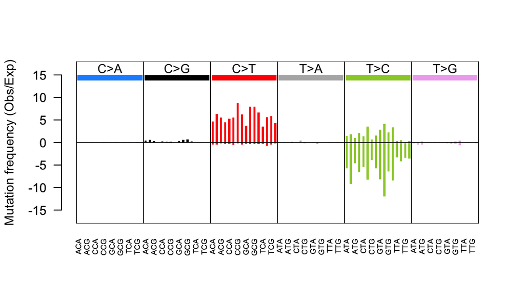

```r
trinucleotide_plot(mutations = df_tidy%>%
                     filter(Sample!="global"&
                              !mut_ref%in%exclude_muts)%>%
                     separate(mut_ref,into=c("chr","pos","ref","mut"))%>%
                     dplyr::rename("donor"=exp_ID)%>%
                     mutate(pos=as.numeric(pos)),
                   analysis_region = "all_mtDNA",
                   analysis_type = "obs_exp",
                   file_name = plot_file(paste0(plots_dir,"Mutational_signature.pdf")))
```

Now limit to check the 0.5 - 1% VAF mutations.

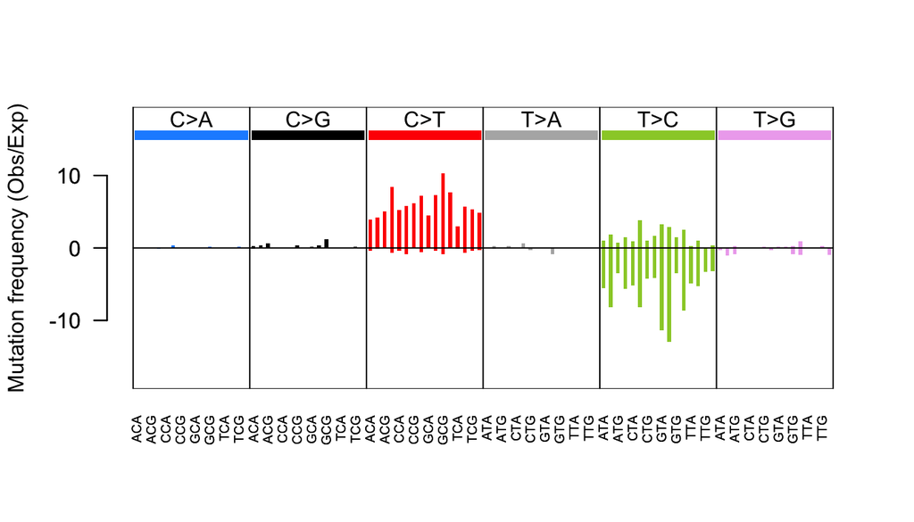

```r
trinucleotide_plot(mutations = df_tidy%>%
                     filter(Sample!="global"&
                              !mut_ref%in%exclude_muts&
                              vaf<0.01 & vaf>0.005)%>%
                     separate(mut_ref,into=c("chr","pos","ref","mut"))%>%
                     dplyr::rename("donor"=exp_ID)%>%
                     mutate(pos=as.numeric(pos)),
                   analysis_region = "all_mtDNA",
                   analysis_type = "obs_exp",
                   file_name = plot_file(paste0(plots_dir,"Mutational_signature_0.005_0.01.pdf")))
```

Now check the <0.5 VAF mutations.

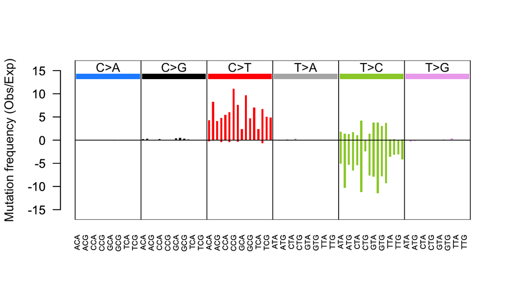

```r
trinucleotide_plot(mutations = df_tidy%>%
                     filter(Sample!="global"&
                              !mut_ref%in%exclude_muts&
                              vaf<0.005)%>%
                     separate(mut_ref,into=c("chr","pos","ref","mut"))%>%
                     dplyr::rename("donor"=exp_ID)%>%
                     mutate(pos=as.numeric(pos)),
                   analysis_region = "all_mtDNA",
                   analysis_type = "obs_exp",
                   file_name = plot_file(paste0(plots_dir,"Mutational_signature_<0.005.pdf")))
```

## ANALYSIS OF MUTATION BURDEN ACCORDING TO CLONE EXPANSION/ SINGLETON

Do clonal expansions have higher mutation burdens compared to singleton colonies? Need to take into account that different cells within a clade are not independent, therefore take an average This may slightly alter the distribution of mutation burdens as some of the variation is smoothed out (might effect the k-s test statistic) Therefore, could alternatively randomly pick a single sample.

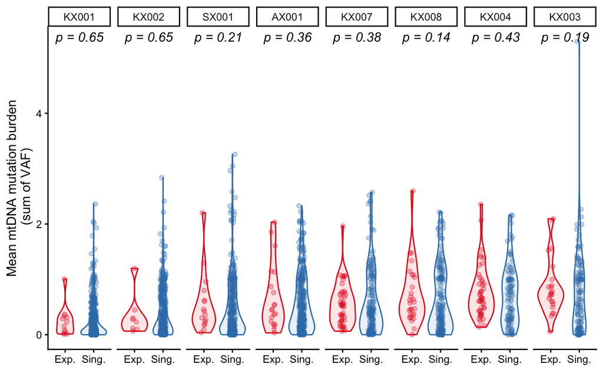

```r
exp_vs_singleton_sov<-Map(list=mito_data[3:10],exp_ID=names(mito_data)[3:10],function(list,exp_ID) {

  #Using the 'get_expanded_clade_nodes' function to effectively cut across the tree at 100 mutations of molecular time
  #Some of the clades will be singletons
  ec_df<-get_expanded_clade_nodes(list$tree.ultra,height_cut_off = 100,min_clonal_fraction = 0,min_samples=1)

  ec_df$mean_sov<-sapply(ec_df$nodes,function(node) {
    Samples<-getTips(list$tree.ultra,node=node)
    mean_sov_in_clade<-sum_of_vaf_df%>%filter(Sample%in%Samples)%>%pull(sum_of_vaf)%>%mean(na.rm=T)
    return(mean_sov_in_clade)
  })

  return(ec_df%>%mutate(exp_ID=exp_ID,.before=1))

})%>%dplyr::bind_rows()

exp_vs_singleton_sov%>%
  mutate(exp_ID=factor(exp_ID,levels=ref_df%>%filter(Age>0)%>%arrange(Age)%>%pull(Sample)))%>%
  mutate(type=ifelse(n_samples==1,"Sing.","Exp."))%>%
  ggplot(aes(x=type,y=mean_sov,col=type,fill=type))+
  geom_violin(alpha=0.1)+
  geom_jitter(width=0.1,height=0,alpha=0.3)+
  scale_color_brewer(palette="Set1")+
  scale_fill_brewer(palette="Set1")+
  facet_grid(~exp_ID)+
  theme_classic()+
  theme(legend.position="none")+
  ggpubr::stat_compare_means(method = "wilcox.test",label = "p.format",fontface="italic")+
  labs(x="",y="Mean mtDNA mutation burden\n (sum of VAF)")
```

```r
all.ks.tests<-lapply(unique(exp_vs_singleton_sov$exp_ID),function(this_exp_ID) {
  ks<-ks.test(x=exp_vs_singleton_sov%>%filter(n_samples==1 & exp_ID==this_exp_ID)%>%pull(mean_sov),
          y=exp_vs_singleton_sov%>%filter(n_samples>1 & exp_ID==this_exp_ID)%>%pull(mean_sov))
  return(ks)
})

p.adjust(sapply(all.ks.tests,function(res) res$p.value),method = "BH")
```

```
## [1] 0.6582285 0.4838963 0.1268002 0.2026133 0.2026133 0.1268002 0.2026133
## [8] 0.6396548
```

## Mutation burden by driver status: mut/ wt

Step 1. Add basic nDNA driver mutation info to the object

```r
mito_data<-Map(list=mito_data,exp_ID=names(mito_data),function(list,exp_ID) {
  annot_muts_file<-paste0(root_dir,"/data/blood_adult/annot_files_filtered/annotated_muts_filt_",exp_ID,".Rds")
  if(file.exists(annot_muts_file)) {
    cat(paste("Importing annotated mutations dataframe for",exp_ID),sep="\n")
    list$nDNA_mats<-readRDS(annot_muts_file)

    if(nrow(list$nDNA_mats$mat)==0) {
      stop(return(list))
    }

    tree_samples<-list$tree.ultra$tip.label[-which(list$tree.ultra$tip.label=="Ancestral")]

    if(any(!tree_samples%in%colnames(list$nDNA_mats$NV))) {
      cat("Dropping samples not found in the count matrix.")
      drop_tips<-tree_samples[!tree_samples%in%colnames(list$nDNA_mats$NV)]
      list$tree.ultra<-drop.tip(list$tree.ultra,tip = drop_tips)
      list$tree<-drop.tip(list$tree,tip = drop_tips)
      tree_samples<-tree_samples[tree_samples%in%colnames(list$nDNA_mats$NV)]
    }

    mtr<-as.matrix(cbind(list$nDNA_mats$NV[,tree_samples,drop=F],matrix(0,ncol = 1,nrow = nrow(list$nDNA_mats$NV),dimnames = list(rownames(list$nDNA_mats$NV),"Ancestral"))))
    dep<-as.matrix(cbind(list$nDNA_mats$NR[,tree_samples,drop=F],matrix(10,ncol = 1,nrow = nrow(list$nDNA_mats$NR),dimnames = list(rownames(list$nDNA_mats$NV),"Ancestral"))))
    res<-treemut::assign_to_tree(tree=list$tree.ultra,mtr=mtr,dep=dep)
    list$nDNA_mats$mat$node<-res$tree$edge[res$summary$edge_ml,2]
    return(list)
  } else {
    return(list)
  }
})
```

[output not shown]

[output cut: 35 more lines]

```
## Loglik= -632.4447
## Finished assigning mutations
## calculating pvalues
## Importing annotated mutations dataframe for AX001
## Initialising edge lengths to 1
## delta edge length= 79.22222
## Loglik= -621.2592
## delta edge length= 0.002372728
## Loglik= -621.2069
## delta edge length= 7.024439e-06
## Loglik= -621.1959
## delta edge length= 2.33967e-08
## Loglik= -621.1958
## Finished assigning mutations
## calculating pvalues
```

Step 2. Generate a similar ‘sum of vaf’ dataframe, but now incorporating driver information

```r
sov_comparison_df<-Map(list=mito_data[3:10],exp_ID=names(mito_data)[3:10],function(list,exp_ID) {
  cat(exp_ID,sep="\n")
  #Using the 'get_expanded_clade_nodes' function to effectively cut across the tree at 100 mutations of molecular time
  #Some of the clades will be singletons
  ec_df<-get_expanded_clade_nodes(list$tree.ultra,height_cut_off = 100,min_clonal_fraction = 0,min_samples=1)

  ec_df$mean_sov<-sapply(ec_df$nodes,function(node) {
    Samples<-getTips(list$tree.ultra,node=node)
    mean_sov_in_clade<-sum_of_vaf_df%>%filter(Sample%in%Samples)%>%pull(sum_of_vaf)%>%mean(na.rm=T)
    return(mean_sov_in_clade)
  })

  left_join(ec_df,list$nDNA_mats$mat%>%dplyr::select(node,mut_ref,Gene,CDS,Protein),by=c("nodes"="node"))%>%
    mutate(exp_ID=exp_ID,.before=1)

})%>%dplyr::bind_rows()
```

```
## KX001
## KX002
## KX003
## KX004
## KX007
## KX008
## SX001
## AX001
```

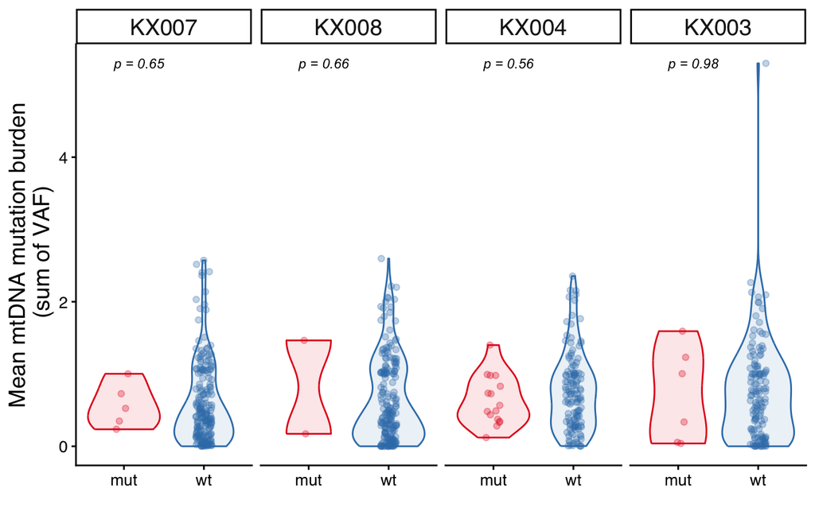

```r
# Split samples by whether they harbour a DTA driver mutation or not
mut_set=c("DNMT3A","TET2","ASXL1")
IDs_to_include=paste0("KX00",c(7,8,4,3))

sov_mut_vs_wt_df<-sov_comparison_df%>%
  mutate(exp_ID=factor(exp_ID,levels=ref_df%>%filter(Age>0)%>%arrange(Age)%>%pull(Sample)))%>%
  replace_na(list(Gene=""))%>%
  mutate(type=ifelse(Gene%in%mut_set,"mut","wt"))%>%
  filter(exp_ID%in%IDs_to_include)

sov_mut_vs_wt<-sov_mut_vs_wt_df%>%
  ggplot(aes(x=type,y=mean_sov,col=type,fill=type))+
  geom_violin(alpha=0.1)+
  geom_jitter(width=0.1,height=0,alpha=0.3)+
  scale_color_brewer(palette="Set1")+
  scale_fill_brewer(palette="Set1")+
  facet_grid(~exp_ID)+
  theme_classic()+
  my_markdown_theme+
  theme(legend.position="none")+
  ggpubr::stat_compare_means(method = "wilcox.test",label = "p.format",fontface="italic",vjust = +0.5,size=3)+
  labs(x="",y="Mean mtDNA mutation burden\n (sum of VAF)")

sov_mut_vs_wt
```

```r
save_plot(filename = paste0(plots_dir,"sov_mut_vs_wt.pdf"),sov_mut_vs_wt,width=3.3,height=2.5)
```

Do a formal regression using a linear mixed effects model: does the mutation burden differ by driver status? Individual is included here as a random effect.

```r
mut_vs_wt.lmer<-lmerTest::lmer(mean_sov~type+(1|exp_ID),data=sov_mut_vs_wt_df)
summary(mut_vs_wt.lmer)
```

```
## Linear mixed model fit by REML. t-tests use Satterthwaite's method [
## lmerModLmerTest]
## Formula: mean_sov ~ type + (1 | exp_ID)
##    Data: sov_mut_vs_wt_df
##
## REML criterion at convergence: 1219.5
##
## Scaled residuals:
##     Min      1Q  Median      3Q     Max
## -1.2264 -0.7860 -0.2256  0.5972  7.7694
##
## Random effects:
##  Groups   Name        Variance Std.Dev.
##  exp_ID   (Intercept) 0.00447  0.06686
##  Residual             0.34689  0.58898
## Number of obs: 680, groups:  exp_ID, 4
##
## Fixed effects:
##              Estimate Std. Error        df t value Pr(>|t|)
## (Intercept)   0.62722    0.11523 145.90768   5.443 2.16e-07 ***
## typewt        0.04855    0.11308 670.81308   0.429    0.668
## ---
## Signif. codes:  0 '***' 0.001 '**' 0.01 '*' 0.05 '.' 0.1 ' ' 1
##
## Correlation of Fixed Effects:
##        (Intr)
## typewt -0.936
```

```r
confint(mut_vs_wt.lmer)
```

```
## Computing profile confidence intervals ...
```

```
##                  2.5 %    97.5 %
## .sig01       0.0000000 0.1654845
## .sigma       0.5585193 0.6213746
## (Intercept)  0.4057790 0.8528671
## typewt      -0.1793800 0.2666071
```

## Mutation burden by clone status: singleton vs part of clone

Assign cells as to whether they are unrelated to any other cell after development (defined here as after 100 mutations of molecular time, although the exact cut off has little impact on results as long at is is ~50 - 150). Now “mut_samples” means that they are part of a clonal expansion (≥2 cells related after development) “wt_samples” means that they are singletons.

```r
mut_vs_wt_list<-Map(list=mito_data[5:8],exp_ID=names(mito_data)[5:8],function(list,exp_ID) {
  cat(exp_ID,sep="\n")
  #Using the 'get_expanded_clade_nodes' function to effectively cut across the tree at 100 mutations of molecular time
  #Some of the clades will be singletons
  ec_df<-get_expanded_clade_nodes(list$tree.ultra,height_cut_off = 100,min_clonal_fraction = 0,min_samples=1)%>%
    left_join(list$nDNA_mats$mat%>%dplyr::select(node,mut_ref,Gene,CDS,Protein),by=c("nodes"="node"))%>%
    mutate(exp_ID=exp_ID,.before=1)

  mut_nodes<-ec_df%>%filter(n_samples>1)%>%pull(nodes)
  wt_nodes<-ec_df%>%filter(n_samples==1)%>%pull(nodes)

  mut_samples<-unlist(lapply(mut_nodes,function(node) sample(x=getTips(list$tree.ultra,node=node),size=1)))
  wt_samples<-unlist(lapply(wt_nodes,function(node) sample(x=getTips(list$tree.ultra,node=node),size=1)))

  return(list(mut=mut_samples,wt=wt_samples))
})
```

```
## KX003
## KX004
## KX007
## KX008
```

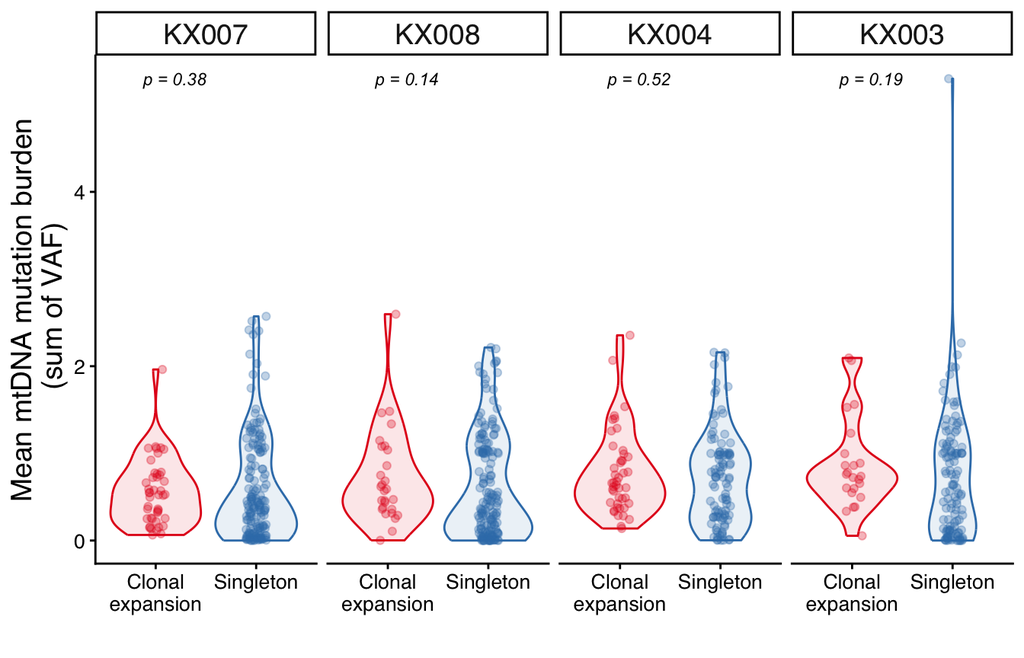

```r
all_mut<-unlist(lapply(mut_vs_wt_list,function(x) x$mut))
all_wt<-unlist(lapply(mut_vs_wt_list,function(x) x$wt))

IDs_to_include=paste0("KX00",c(7,8,4,3))

exp_vs_singleton_df<-sov_comparison_df%>%
  mutate(exp_ID=factor(exp_ID,levels=ref_df%>%filter(Age>0)%>%arrange(Age)%>%pull(Sample)))%>%
  filter(exp_ID%in%IDs_to_include)%>%
  mutate(type=ifelse(n_samples>1,"Clonal\nexpansion",ifelse(n_samples==1,"Singleton",NA)))%>%
  filter(!is.na(type))

sov_exp_vs_singleton<-exp_vs_singleton_df%>%
  ggplot(aes(x=type,y=mean_sov,col=type,fill=type))+
  geom_violin(alpha=0.1)+
  geom_jitter(width=0.1,height=0,alpha=0.3)+
  scale_color_brewer(palette="Set1")+
  scale_fill_brewer(palette="Set1")+
  facet_grid(~exp_ID)+
  theme_classic()+
  my_markdown_theme+
  theme(legend.position="none",axis.text.x=element_text(angle=0))+
  ggpubr::stat_compare_means(method = "wilcox.test",label = "p.format",fontface="italic",vjust = +0.5,size=3)+
  labs(x="",y="Mean mtDNA mutation burden\n (sum of VAF)")

sov_exp_vs_singleton
```

```r
save_plot(filename = paste0(plots_dir,"sov_exp_vs_singleton.pdf"),sov_exp_vs_singleton,width=3.3,height=2.5)
```

Again, do a formal regression with a linear mixed effects regression model.

```r
exp_vs_singleton_df%>%group_by(type)%>%dplyr::summarise(n=n())
```

```
## # A tibble: 2 × 2
##   type                    n
##   <chr>               <int>
## 1 "Clonal\nexpansion"   140
## 2 "Singleton"           540
```

```r
exp_vs_singleton.lmer<-lmerTest::lmer(mean_sov~type+(1|exp_ID),data=exp_vs_singleton_df)
summary(exp_vs_singleton.lmer)
```

```
## Linear mixed model fit by REML. t-tests use Satterthwaite's method [
## lmerModLmerTest]
## Formula: mean_sov ~ type + (1 | exp_ID)
##    Data: exp_vs_singleton_df
##
## REML criterion at convergence: 1220.4
##
## Scaled residuals:
##     Min      1Q  Median      3Q     Max
## -1.2055 -0.7870 -0.2447  0.6069  7.7926
##
## Random effects:
##  Groups   Name        Variance Std.Dev.
##  exp_ID   (Intercept) 0.004083 0.0639
##  Residual             0.346715 0.5888
## Number of obs: 680, groups:  exp_ID, 4
##
## Fixed effects:
##                Estimate Std. Error        df t value Pr(>|t|)
## (Intercept)     0.71101    0.05937  15.39627  11.976  3.3e-09 ***
## typeSingleton  -0.04762    0.05628 675.77247  -0.846    0.398
## ---
## Signif. codes:  0 '***' 0.001 '**' 0.01 '*' 0.05 '.' 0.1 ' ' 1
##
## Correlation of Fixed Effects:
##             (Intr)
## typeSingltn -0.750
```

```r
confint(exp_vs_singleton.lmer)
```

```
## Computing profile confidence intervals ...
```

```
##                    2.5 %     97.5 %
## .sig01         0.0000000 0.15997376
## .sigma         0.5583691 0.62120459
## (Intercept)    0.5962259 0.82671075
## typeSingleton -0.1586329 0.06196431
```

## SELECTION ANALYSIS

This section uses two approaches to look for evidence of selection for or against mtDNA mutations.

1. Cumulative distribution function of heteroplasmy levels, divided by the mutation impact (i.e. synonymous, missense or nonsense).
2. dN/dS. This is the ratio of non-synonymous mutations compared to synonymous, corrected such that the anticipated ratio by chance is 1. A ratio of >1 implies overall positive selection (i.e. there is an excess of non-synonymous variants), a ratio of <1 implies overall negative selection (i.e. there is a depletion of non-synonymous variants), and a ratio of ~1 implies overall neutrality.

```r
library(dndscv)
mtref_rda_path=ifelse(Sys.info()['sysname']=="Darwin",paste0(root_dir,"/data/mtref.rda"),"/lustre/scratch126/casm/team154pc/ms56/Mitochondria_study/mtref.rda")
mtref_rda_path="~/Downloads/mtref.rda"
input.dir <- paste0(root_dir,"/dnds_tables/")

dnds_theme<-theme(panel.border = element_rect(color = "black",
                                              fill = NA,
                                              linewidth = 0.75),
                  strip.text = element_text(face="plain", size=6, colour = "black",),
                  strip.background = element_rect(fill="white", colour="black", linewidth =1),
                  axis.text.x = element_text(color = "black", size = 6, angle = 0, hjust = .5, vjust = 0.5, face = "plain"),
                  axis.text.y = element_text(color = "black", size = 6, angle = 0, hjust = 1, vjust = 0, face = "plain"),
                  axis.title.x = element_text(color = "black", size = 8, angle = 0, hjust = .5, vjust = 0, face = "plain"),
                  axis.title.y = element_text(color = "black", size = 8, angle = 90, hjust = .5, vjust = .5, face = "plain",
                                              margin = margin(t = 0, r = 10, b = 0, l = 0)),
                  plot.title = element_text(color = "black", size = 10, hjust = .5, face = "plain"),
                  legend.position = "right")

#exclude ND6 from analysis since its on the other strand
all_mtDNA_genes <- c("MT-CYB", "MT-ND5", "MT-ND2", "MT-ND4", "MT-ND1", "MT-CO3", "MT-ATP6","MT-ND3", "MT-ATP8", "MT-ND4L", "MT-CO2", "MT-CO1","MT-ND5","MT-ND6")
target_genes <- c("MT-CYB", "MT-ND5", "MT-ND2", "MT-ND4", "MT-ND1", "MT-CO3", "MT-ATP6","MT-ND3", "MT-ATP8", "MT-ND4L", "MT-CO2", "MT-CO1")

# This labels each sample as foetal, cord blood or adult
df_tidy$Tissue<-ifelse(grepl("pcw",df_tidy$exp_ID),"Foetal blood",ifelse(grepl("CB",df_tidy$exp_ID),"Cord blood","Adult blood"))
valid.tissues <- unique(df_tidy$Tissue)

df_tidy_annotated<-lapply("x",function(tissue.id) {
  cat(tissue.id,sep="\n")

  # read in the mtdna variant file and remove patient id
  mtdna.variant.data <- df_tidy%>%
    #dplyr::filter(Tissue==tissue.id)%>%
    separate("mut_ref", c("chr", "pos", "ref", "mut"), "_")%>%
    mutate(pos=as.numeric(pos))%>%
    dplyr::select("sampleID"=Sample,chr,pos,ref,mut,vaf)%>% # next, rename/reorder the columns to make them compatible with dnds input format
    dplyr::filter(!duplicated(.))%>% # remove duplicated variants
    arrange(sampleID,pos)

  # run dnds with the mtDNA variants to annotate them (the selection analysis isn't actually used here)
  mtdna.dndsout <- dndscv(mtdna.variant.data,
                          gene_list=all_mtDNA_genes,
                          refdb = mtref_rda_path,
                          numcode = 2,
                          max_coding_muts_per_sample = Inf,
                          max_muts_per_gene_per_sample = Inf)

  # get the results with the annotated variants
  annotated.mtdna.variants <- left_join(mtdna.variant.data,mtdna.dndsout$annotmuts,by=c("sampleID","chr","pos","ref","mut"))%>%
    tidyr::replace_na(replace=list(impact="Non-Coding"))%>%
    mutate(tissue=tissue.id,.before=1)
  return(annotated.mtdna.variants)
})%>%dplyr::bind_rows()
```

```
## x
```

```r
complete.annotated.mutation.table<-df_tidy_annotated%>%
  left_join(df_tidy%>%dplyr::bind_rows()%>%dplyr::select(Sample,exp_ID),by=c("sampleID"="Sample"),relationship="many-to-many")%>%
  dplyr::rename("patientID"=exp_ID)%>%
  filter(!duplicated(.))%>%
  arrange(patientID,pos)%>% # order the dataframe
  tidyr::unite(col="mut_ref",chr,pos,ref,mut,sep="_",remove=F)

head(complete.annotated.mutation.table)
```

```
##   tissue      sampleID    mut_ref chr pos ref mut         vaf gene strand
## 1      x PD41768hn_hum  MT_37_A_G  MT  37   A   G 0.005025126 <NA>     NA
## 2      x PD41768dp_hum  MT_58_T_C  MT  58   T   C 0.010190217 <NA>     NA
## 3      x PD41768gs_hum  MT_58_T_C  MT  58   T   C 0.035369775 <NA>     NA
## 4      x PD41768aq_hum  MT_71_G_A  MT  71   G   A 0.006404782 <NA>     NA
## 5      x  PD41768c_hum MT_198_C_T  MT 198   C   T 0.011436741 <NA>     NA
## 6      x PD41768dc_hum MT_198_C_T  MT 198   C   T 0.048846676 <NA>     NA
##   ref_cod mut_cod ref3_cod mut3_cod aachange ntchange codonsub     impact  pid
## 1    <NA>    <NA>     <NA>     <NA>     <NA>     <NA>     <NA> Non-Coding <NA>
## 2    <NA>    <NA>     <NA>     <NA>     <NA>     <NA>     <NA> Non-Coding <NA>
## 3    <NA>    <NA>     <NA>     <NA>     <NA>     <NA>     <NA> Non-Coding <NA>
## 4    <NA>    <NA>     <NA>     <NA>     <NA>     <NA>     <NA> Non-Coding <NA>
## 5    <NA>    <NA>     <NA>     <NA>     <NA>     <NA>     <NA> Non-Coding <NA>
## 6    <NA>    <NA>     <NA>     <NA>     <NA>     <NA>     <NA> Non-Coding <NA>
##   patientID
## 1     18pcw
## 2     18pcw
## 3     18pcw
## 4     18pcw
## 5     18pcw
## 6     18pcw
```

### Compare annotation with nuclear vs mitochondrial genetic code.

Run analysis with the (incorrect) nuclear annotation for comparison. This is because in an initial version of the analysis, we used the incorrect genetic code, so want to show here how this initially altered the results, and how it compares with the correct annotation.

```r
df_tidy_annotated_NUC<-lapply("x",function(tissue.id) {
  cat(tissue.id,sep="\n")

  # read in the mtdna variant file and remove patient id
  mtdna.variant.data <- df_tidy%>%
    #dplyr::filter(Tissue==tissue.id)%>%
    separate("mut_ref", c("chr", "pos", "ref", "mut"), "_")%>%
    mutate(pos=as.numeric(pos))%>%
    dplyr::select("sampleID"=Sample,chr,pos,ref,mut,vaf)%>% # next, rename/reorder the columns to make them compatible with dnds input format
    dplyr::filter(!duplicated(.))%>% # remove duplicated variants
    arrange(sampleID,pos)

  # run dnds with the mtDNA variants to annotate them (the selection analysis isn't actually used here)
  mtdna.dndsout <- dndscv(mtdna.variant.data,
                          gene_list=all_mtDNA_genes,
                          refdb = mtref_rda_path,
                          numcode = 1,
                          max_coding_muts_per_sample = Inf,
                          max_muts_per_gene_per_sample = Inf)

  # get the results with the annotated variants
  annotated.mtdna.variants <- left_join(mtdna.variant.data,mtdna.dndsout$annotmuts,by=c("sampleID","chr","pos","ref","mut"))%>%
    tidyr::replace_na(replace=list(impact="Non-Coding"))%>%
    mutate(tissue=tissue.id,.before=1)
  return(annotated.mtdna.variants)
})%>%dplyr::bind_rows()
```

```
## x
```

```r
complete.annotated.mutation.table.NUC<-df_tidy_annotated_NUC%>%
  left_join(df_tidy%>%dplyr::bind_rows()%>%dplyr::select(Sample,exp_ID),by=c("sampleID"="Sample"),relationship="many-to-many")%>%
  dplyr::rename("patientID"=exp_ID)%>%
  filter(!duplicated(.))%>%
  arrange(patientID,pos)%>% # order the dataframe
  #mutate(impact=ifelse(impact%in%c("Stop_loss","Nonsense"),"Truncating",impact))%>% #rename stop loss and nonsense mutations
  tidyr::unite(col="mut_ref",chr,pos,ref,mut,sep="_",remove=F)
```

Here we show how the incorrect annotation changes the numbers of mutations with different consequences (i.e. truncating vs missense vs synonymous)

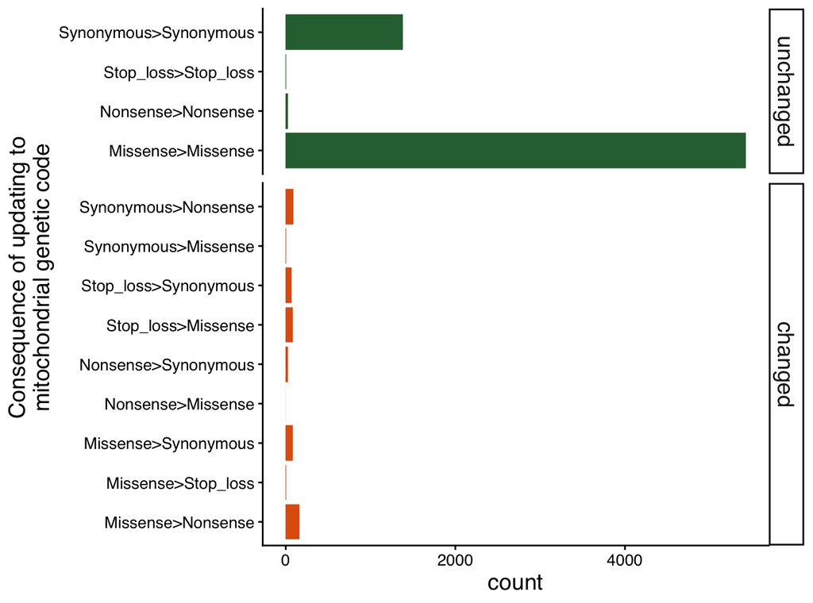

```r
## Plots of nuclear vs mitochondrial annotation----
impact_comparison_df<-left_join(complete.annotated.mutation.table,
                                complete.annotated.mutation.table.NUC%>%dplyr::select(tissue,sampleID,mut_ref,codonsub,"impact_NUC"=impact))%>%
  dplyr::select(tissue,sampleID,mut_ref,codonsub,impact,impact_NUC)
consequence_change_plot<-impact_comparison_df%>%
  mutate(change=paste(impact_NUC,impact,sep=">"))%>%
  mutate(altered=ifelse(impact_NUC==impact,"unchanged","changed"))%>%
  filter(impact!="Non-Coding")%>%
  mutate(altered=factor(altered,levels=c("unchanged","changed")))%>%
  ggplot(aes(y=change,fill=altered))+
  geom_bar()+
  facet_grid(rows=vars(altered),scales="free",space="free_y")+
  theme_classic()+
  scale_fill_manual(values=rev(c("#e06010","#2d6e3e")),guide="none")+
  my_markdown_theme+
  labs(y="Consequence of updating to\nmitochondrial genetic code")

consequence_change_plot
```

```r
save_plot(filename = paste0(plots_dir,"consequence_change_plot.pdf"),consequence_change_plot,width=3.5,height=2.5)
```

```r
impact_comparison_df%>%
  filter(impact!="Non-Coding")%>%
  mutate(change=paste(impact_NUC,impact,sep=">"))%>%
  mutate(altered=ifelse(impact_NUC==impact,"unchanged","changed"))%>%
  pull(altered)%>%table()
```

```
## .
##   changed unchanged
##       518      6835
```

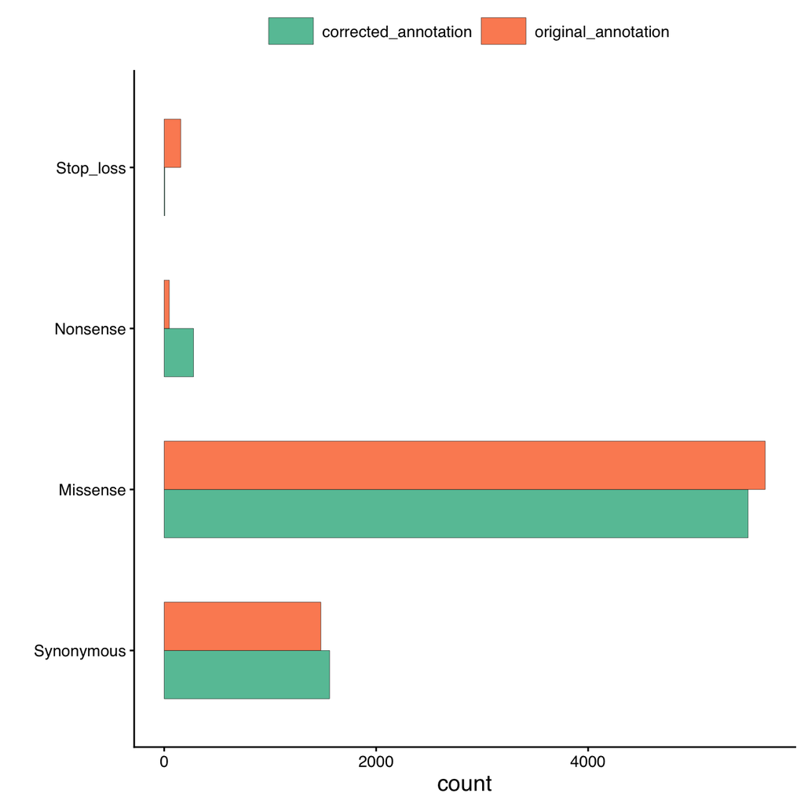

```r
total_numbers_old_vs_new_plot<-impact_comparison_df%>%
  dplyr::select(mut_ref,"corrected_annotation"=impact,"original_annotation"=impact_NUC)%>%
  tidyr::gather(-mut_ref,key="annotation",value="impact")%>%
  filter(impact!="Non-Coding")%>%
  mutate(impact=factor(impact,levels=c("Synonymous","Missense","Nonsense","Stop_loss")))%>%
  ggplot(aes(y = impact,fill=annotation))+
  geom_bar(position="dodge",width=0.6,col="black",linewidth=0.1)+
  scale_fill_brewer(palette="Set2")+
  theme_classic()+
  my_markdown_theme+
  labs(fill="",y="")+
  theme(legend.position = "top")

total_numbers_old_vs_new_plot
```

```r
save_plot(filename = paste0(plots_dir,"total_numbers_old_vs_new_plot.pdf"),total_numbers_old_vs_new_plot,width=3,height=2.5)
```

```r
impact_comparison_df%>%
  dplyr::select(mut_ref,"new_annotation"=impact,"original_annotation"=impact_NUC)%>%
  tidyr::gather(-mut_ref,key="annotation",value="impact")%>%
  filter(impact!="Non-Coding")%>%
  dplyr::group_by(annotation,impact)%>%
  dplyr::summarise(n=n())
```

```
## `summarise()` has regrouped the output.
## ℹ Summaries were computed grouped by annotation and impact.
## ℹ Output is grouped by annotation.
## ℹ Use `summarise(.groups = "drop_last")` to silence this message.
## ℹ Use `summarise(.by = c(annotation, impact))` for per-operation grouping
##   (`?dplyr::dplyr_by`) instead.
```

```
## # A tibble: 8 × 3
## # Groups:   annotation [2]
##   annotation          impact         n
##   <chr>               <chr>      <int>
## 1 new_annotation      Missense    5510
## 2 new_annotation      Nonsense     277
## 3 new_annotation      Stop_loss      5
## 4 new_annotation      Synonymous  1561
## 5 original_annotation Missense    5671
## 6 original_annotation Nonsense      48
## 7 original_annotation Stop_loss    156
## 8 original_annotation Synonymous  1478
```

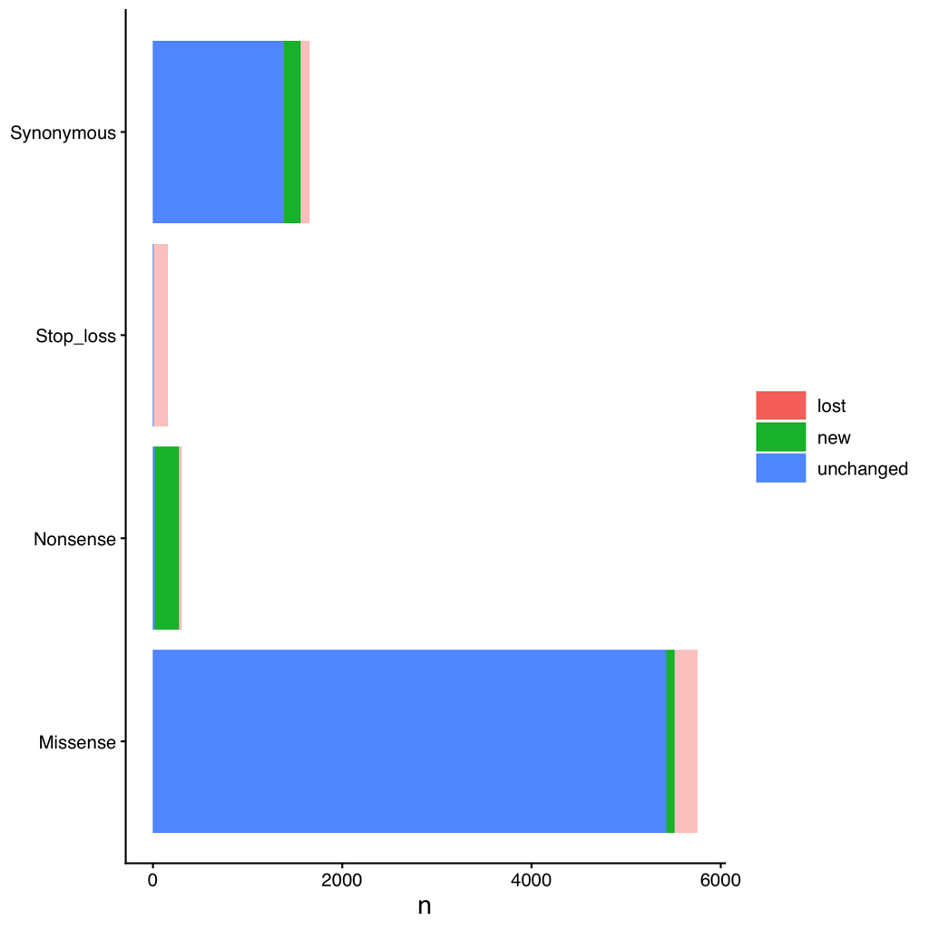

```r
simple_impact_comparison_df<-impact_comparison_df%>%
  mutate(change=paste(impact_NUC,impact,sep=">"))%>%
  mutate(altered=ifelse(impact_NUC==impact,"unchanged","changed"))

new_muts<-simple_impact_comparison_df%>%
  filter(altered=="changed")%>%
  group_by(impact)%>%
  dplyr::summarise(new=n())

lost_muts<-simple_impact_comparison_df%>%
  filter(altered=="changed")%>%
  group_by(impact_NUC)%>%
  dplyr::summarise(lost=n())%>%dplyr::rename("impact"=impact_NUC)

simple_impact_comparison_df%>%
  filter(altered=="unchanged" & impact!="Non-Coding")%>%
  group_by(impact)%>%
  dplyr::summarise(unchanged=n())%>%
  left_join(new_muts)%>%left_join(lost_muts)%>%
  tidyr::gather(-impact,key="result",value="n")%>%
  ggplot(aes(y=impact,x=n,fill=result,alpha = result!="lost"))+
  geom_bar(stat="identity")+
  scale_alpha(range=c(0.4,1),guide="none")+
  theme_classic()+
  my_markdown_theme+
  theme(axis.title.y=element_blank(),legend.title = element_blank())
```

### Look at the numbers of synonymous/ non-synonymous mutations

```r
my_comparisons <- list(c("Missense", "Synonymous"),
                       c("Synonymous", "Nonsense"))

mutation_category_by_vaf_violin_plot<-complete.annotated.mutation.table%>%
  dplyr::filter(impact!="Non-Coding"&impact!="Stop_loss")%>%
  ggplot(aes(impact, vaf, color = impact)) +
  geom_violin(aes(fill=impact),alpha=0.2) +
  geom_jitter(width=0.25,size = .1, alpha = 0.1) +
  theme_classic() +
  scale_color_manual(values=mut_type_cols) +
  scale_fill_manual(values=mut_type_cols) +
  scale_y_log10() +
  #facet_wrap(~ tissue, scales='free_x', nrow = 1) +
  theme(axis.text.x = element_text(angle=45, vjust=0.5)) +
  ggpubr::stat_compare_means(comparisons = my_comparisons, size = 2) +
  labs(x="",y="Variant allele fraction",col="Impact",fill="Impact") +
  my_markdown_theme+
  theme(legend.position="none")
```

```
## `stat_compare_means()` with `comparisons` displays *unadjusted* p-values (no correction for multiple comparisons).
## ℹ For p-values adjusted for multiple comparisons, use `geom_pwc()`, or `stat_pvalue_manual()` together with `compare_means(..., p.adjust.method = )`.
```

```r
#Gives some sense of differing heteroplasmy distributions
#But bear in mind there are multiple non-independent measures for some variants
#Would need to account for this e.g. by taking single measure of e.g. max VAF of variant per individual
syn_vals <- complete.annotated.mutation.table %>%
  dplyr::filter(impact == "Synonymous") %>% pull(vaf)

mis_vals <- complete.annotated.mutation.table %>%
  dplyr::filter(impact == "Missense") %>% pull(vaf)

nons_vals <- complete.annotated.mutation.table %>%
  dplyr::filter(impact == "Nonsense") %>% pull(vaf)

ks_syn_mis <- ks.test(syn_vals, mis_vals)
ks_syn_non <- ks.test(syn_vals, nons_vals)
find_ks_coords <- function(vals1, vals2) {
  ecdf1 <- ecdf(vals1)
  ecdf2 <- ecdf(vals2)
  all_y <- sort(c(vals1, vals2))
  diffs <- abs(ecdf1(all_y) - ecdf2(all_y))
  max_y <- all_y[which.max(diffs)]
  data.frame(
    y    = max_y,
    xmin = min(ecdf1(max_y), ecdf2(max_y)),
    xmax = max(ecdf1(max_y), ecdf2(max_y))
  )
}

fmt_p <- function(p) {
  ifelse(p < 0.001, "p < 0.001",
         ifelse(p < 0.01,  paste0("p = ", round(p, 3)),
                paste0("p = ", round(p, 2))))
}

coords_non <- find_ks_coords(syn_vals, nons_vals)
coords_mis <- find_ks_coords(syn_vals, mis_vals)

sapply(list(mis_vals,nons_vals,syn_vals),length)
```

```
## [1] 5510  277 1561
```

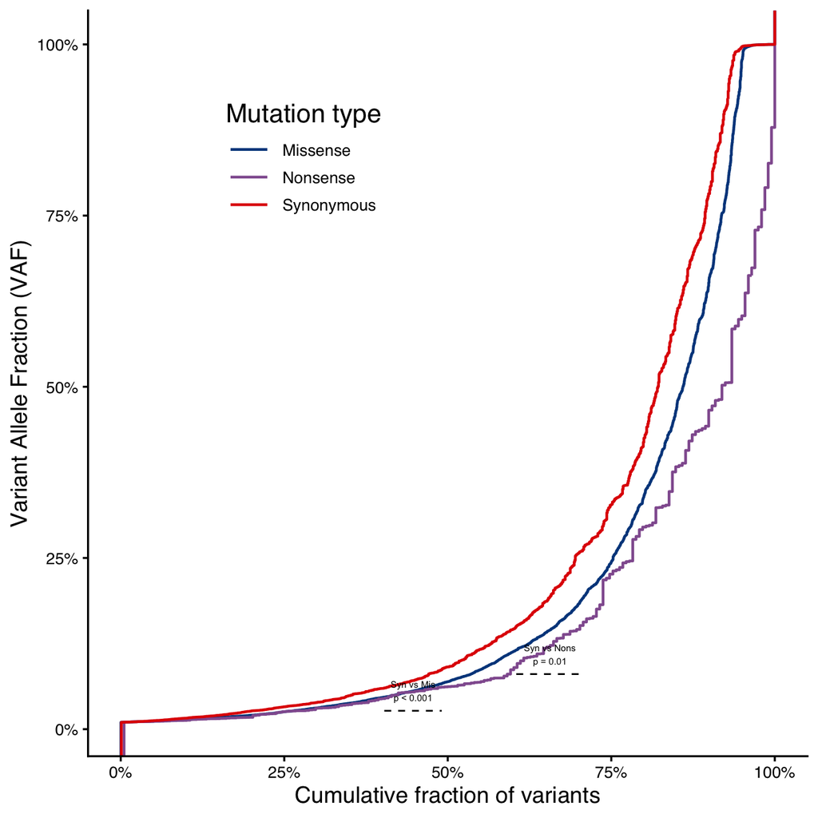

```r
mutation_type_ecdf_plot<-complete.annotated.mutation.table %>%
  filter(impact != "Non-Coding" & impact != "Stop_loss") %>%
  ggplot(aes(y = vaf, col = impact)) +
  stat_ecdf(geom = "step", linewidth = 0.8) +
  # Syn vs Missense segment
  annotate("segment",
           x = coords_mis$xmin, xend = coords_mis$xmax,
           y = coords_mis$y,    yend = coords_mis$y,
           colour = "black", linewidth = 0.5, linetype = "dashed") +
  annotate("text",
           x = mean(c(coords_mis$xmin, coords_mis$xmax)),
           y = coords_mis$y,
           vjust = -0.5, size = 2,
           label = paste0("Syn vs Mis\n", fmt_p(ks_syn_mis$p.value))) +
  # Syn vs Nonsense segment
  annotate("segment",
           x = coords_non$xmin, xend = coords_non$xmax,
           y = coords_non$y,    yend = coords_non$y,
           colour = "black", linewidth = 0.5, linetype = "dashed") +
  annotate("text",
           x = mean(c(coords_non$xmin, coords_non$xmax)),
           y = coords_non$y,
           vjust = -0.5, size = 2,
           label = paste0("Syn vs Nons\n", fmt_p(ks_syn_non$p.value)))+
  scale_y_continuous(limits = c(0.01, 1),
                     labels = scales::percent_format(accuracy = 1),
                     name = "Variant Allele Fraction (VAF)") +
  scale_x_continuous(labels = scales::percent_format(accuracy = 1),
                     name = "Cumulative fraction of variants") +
  theme_classic(base_size = 13) +
  scale_color_manual(values = mut_type_cols) +
  my_markdown_theme +
  theme(panel.grid.minor = element_blank(),
        legend.position = c(0.3, 0.8)) +
  labs(col = "Mutation type")

mutation_type_ecdf_plot
```

```r
save_plot(filename = paste0(plots_dir,"mutation_type_ecdf_plot.pdf"),mutation_type_ecdf_plot,width=2.5,height=2.5)
```

```r
mutation_type_by_gene<-complete.annotated.mutation.table%>%
  filter(impact!="Non-Coding")%>%
  distinct(sampleID,mut_ref,gene,impact)%>%
  group_by(gene,impact)%>%
  dplyr::summarise(n=n())%>%
  ggplot(aes(y=gene,x=n,fill=impact))+
  geom_bar(position="stack",stat="identity",col="black",linewidth=0.1)+
  scale_fill_manual(values=mut_type_cols)+
  scale_x_continuous(breaks=seq(0,1400,200))+
  theme_classic()+
  my_markdown_theme+
  theme(axis.title.y=element_blank(),
        axis.text.y=element_text(face="italic"))+
  labs(x="Number of variants",fill="Mutation\nconsequence")
```

```
## `summarise()` has regrouped the output.
## ℹ Summaries were computed grouped by gene and impact.
## ℹ Output is grouped by gene.
## ℹ Use `summarise(.groups = "drop_last")` to silence this message.
## ℹ Use `summarise(.by = c(gene, impact))` for per-operation grouping
##   (`?dplyr::dplyr_by`) instead.
```

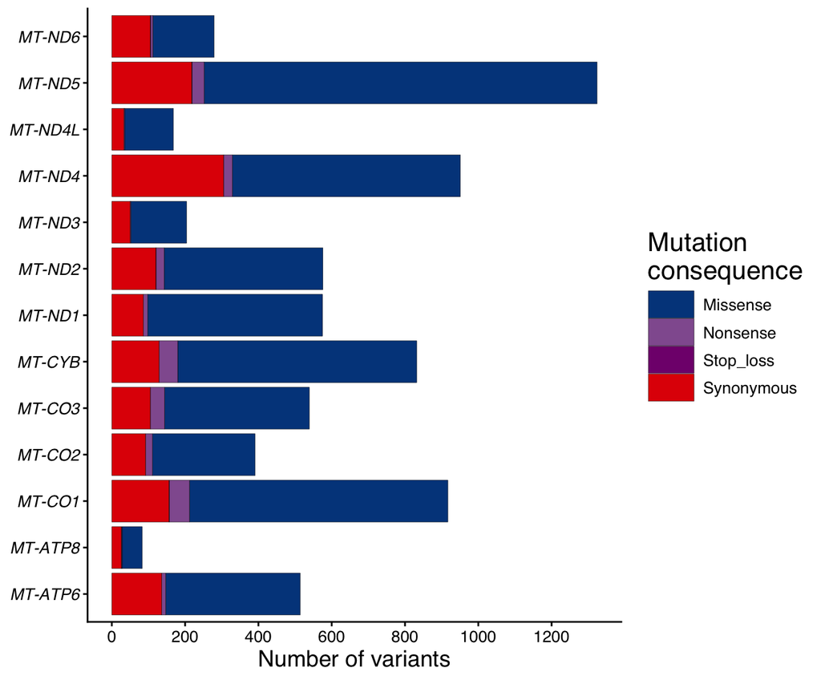

```r
mutation_type_by_gene
```

```r
save_plot(filename = paste0(plots_dir,"mutation_type_by_gene_blood.pdf"),mutation_type_by_gene,width=3.5,height=2.5)
```

### dndscv across the blood individuals

Combine across all the blood individuals and assess the dN/dS ratios of all variants in aggregate. Only count each variant once per individual. As before, using the argument “numcode=2” ensures that the mitochondrial genetic code is used for annotation.

```r
dndscv_by_tissue<-lapply("x",function(tissue.id) {

  cat(tissue.id,sep="\n")
  tissue_info<-df_tidy%>%
    separate("mut_ref", c("chr", "pos", "ref", "mut"), "_")%>%
    mutate(pos=as.numeric(pos))%>%
    dplyr::select("sampleID"=exp_ID,chr,pos,ref,mut)%>%
    dplyr::filter(!duplicated(.))%>%
    arrange(sampleID,pos)

  mtdna.dndsout <- dndscv(tissue_info,
                          gene_list=target_genes,
                          refdb = mtref_rda_path,
                          numcode = 2,
                          max_coding_muts_per_sample = Inf,
                          max_muts_per_gene_per_sample = Inf)
  return(mtdna.dndsout)
})
```

```
## x
```

```r
# processing the output to get a combined 'globaldnds' dataframe by tissue type
rename_vec=c("Missense","Nonsense","Truncating","Overall")
names(rename_vec)=c("wmis","wnon","wtru","wall")

globaldnds_res<-Map(dndsout=dndscv_by_tissue,tissue="x",function(dndsout,tissue) {
  dndsout$globaldnds%>%
    filter(!is.na(name) & complete.cases(.))%>%
    mutate(name=rename_vec[name])%>%
    mutate(tissue=tissue)
})%>%dplyr::bind_rows()

tissue_order=c("Foetal blood","Cord blood","Adult blood")
nb.cols <- length(tissue_order)
mycolors <- colorRampPalette(ggsci::pal_lancet(palette = "lanonc")(9))(nb.cols)
```

Visualize these results

```r
max_dnds_value<-1.3
stats_to_include=c("Missense","Truncating","Overall")
global_dnds_blood<-globaldnds_res%>%
  filter(name%in%stats_to_include)%>%
  mutate(cihigh=ifelse(cihigh>max_dnds_value,max_dnds_value,cihigh),
         tissue=factor(tissue,levels=tissue_order),
         name=factor(name,levels=stats_to_include))%>%
  ggplot(aes(x=name, y = mle, ymin = cilow, ymax = cihigh, color = name, shape = name)) +
  geom_linerange(position= position_dodge2(width=0.75), linewidth = 0.5, color="darkgrey") +
  geom_point(position=position_dodge2(width=0.75), size = 1.5) +
  labs(y = "Mitochondrial genome-wide dN/dS") +
  theme_classic() +
  ylim(c(0.5,max_dnds_value))+
  scale_x_discrete(labels = function(x) str_wrap(x, width = 6))+
  scale_color_manual(values = mut_type_cols, name="Mutation type") +
  scale_shape_manual(values = c(15, 16, 17, 18), name = "Mutation type") +
  geom_hline(yintercept=1, linetype='dashed', col = 'darkgrey', linewidth = 0.5) +
  my_markdown_theme+
  #facet_wrap(~tissue,nrow=1)+
  theme(axis.title.x=element_blank(),
        axis.text.x=element_text(angle=45,vjust = +0.5),
        legend.title=element_blank(),
        legend.position="none")

save_plot(filename = paste0(plots_dir,"global_dnds_blood.pdf"),global_dnds_blood,width=1.3,height=2.5)
```

```r
### Generate Extended Data FIG. 2C ---------
gene_order=c(paste0("MT-ND",1:6),"MT-ND4L","MT-CYB",paste0("MT-CO",1:3),"MT-ATP6","MT-ATP8")
gene_order<-gene_order[gene_order%in%target_genes]

selcv_res_by_tissue<-Map(dndsout=dndscv_by_tissue,tissue="x",function(dndsout,tissue) {
  temp<-dndsout$sel_cv%>%
    dplyr::select(gene_name,wmis_cv,wnon_cv,qmis_cv,qtrunc_cv)

  dplyr::bind_rows(temp%>%dplyr::select(gene_name,"dNdS"=wmis_cv,"qval"=qmis_cv)%>%mutate(type="Missense"),
                   temp%>%dplyr::select(gene_name,"dNdS"=wnon_cv,"qval"=qtrunc_cv)%>%mutate(type="Nonsense"))%>%
    mutate(tissue=tissue)
})%>%dplyr::bind_rows()

qval_cutoff=0.05
dnds_heatmap_by_gene<-selcv_res_by_tissue%>%
  mutate(dnds_if_signif=ifelse(qval<qval_cutoff,paste0(round(dNdS,2),"*"),""),
         gene_name=factor(gene_name,levels=rev(gene_order)))%>%
  ggplot(aes(y=gene_name,x=type,fill=dNdS,label=dnds_if_signif))+
  geom_tile()+
  geom_text(aes(col=type),size=1.6)+
  scale_color_manual(values=c("black","white"),guide="none")+
  theme_classic()+
  my_markdown_theme+
  theme(axis.text.x=element_text(angle=45,vjust=0.5),legend.position="none")+
  scale_fill_gradientn(colors=RColorBrewer::brewer.pal(n=11,name = "RdYlGn"),limits=c(0,2))+
  labs(x="",y="")

save_plot(filename = paste0(plots_dir,"dnds_heatmap_by_gene.pdf"),dnds_heatmap_by_gene,width=1.5,height=2.5)
```

### dndscv - split by heteroplasmy

```r
#Define the VAF 'bins' that will be used for comparing VAF distributions
#Can set this on a log scale, or as decile bins
boundaries<-c(0,0.01,0.1,0.2,0.5,1)
new_VAF_groups=paste0(100*head(boundaries,-1),"-",100*tail(boundaries,-1),"%")
VAF_groups=data.frame(labels=new_VAF_groups,LL=head(boundaries,-1),UL=tail(boundaries,-1))

#Assign each observed VAF into its 'VAF group' bin
df_tidy$VAF_group=sapply(df_tidy$vaf,function(vaf) {
  if(vaf==0) {
    return("Absent")
  } else {
    return(VAF_groups$labels[VAF_groups$LL<vaf & VAF_groups$UL>=vaf])
  }
})


dndscv_by_vaf_blood<-lapply(new_VAF_groups,function(VAF_bin) {
  cat(VAF_bin,sep="\n")
  tissue_vaf_info<-df_tidy%>%
    dplyr::filter(VAF_group==VAF_bin)%>%
    separate("mut_ref", c("chr", "pos", "ref", "mut"), "_")%>%
    mutate(pos=as.numeric(pos))%>%
    dplyr::select("sampleID"=exp_ID,chr,pos,ref,mut)%>%
    dplyr::filter(!duplicated(.))%>% #only count each mutation once per individual in each VAF group
    arrange(sampleID,pos)

  mtdna.dndsout <- dndscv(tissue_vaf_info, gene_list=target_genes,
                          refdb = mtref_rda_path,
                          max_coding_muts_per_sample = Inf,
                          numcode = 2,
                          max_muts_per_gene_per_sample = Inf)
  return(mtdna.dndsout)
})
```

```
## 0-1%
```

```
## 1-10%
```

```
## 10-20%
```

```
## 20-50%
```

```
## 50-100%
```

```r
globaldnds_res_by_vaf<-Map(dndsout=dndscv_by_vaf_blood,VAF_bin=new_VAF_groups,function(dndsout,VAF_bin) {
  dndsout$globaldnds%>%
    filter(!is.na(name) & complete.cases(.))%>%
    mutate(name=rename_vec[name])%>%
    mutate(VAF_group=VAF_bin)
})%>%dplyr::bind_rows()

max_dnds_value<-1.5
stats_to_include=c("Overall")
global_dnds_by_vaf_plot<-globaldnds_res_by_vaf%>%
  filter(VAF_group%in%VAF_groups$labels[-1] & name%in%stats_to_include)%>%
  mutate(cihigh=ifelse(cihigh>max_dnds_value,max_dnds_value,cihigh),
         VAF_group=factor(VAF_group,levels=VAF_groups$labels[-1]))%>%
  ggplot(aes(x=VAF_group, y = mle, ymin = cilow, ymax = cihigh, color = name, shape = name)) +
  geom_linerange(position= position_dodge2(width=0.75), linewidth = 0.5, color="darkgrey") +
  geom_point(position=position_dodge2(width=0.75), size = 1.5) +
  labs(y = "Mitochondrial genome-wide dN/dS", x = "Variant allele fraction") +
  theme_classic() +
  ylim(c(0,max_dnds_value))+
  scale_color_manual(values = mut_type_cols, name="Mutation type") +
  scale_shape_manual(values = 17, name = "Mutation type") +
  geom_hline(yintercept=1, linetype='dashed', col = 'darkgrey', linewidth = 0.5) +
  theme_classic()+
  my_markdown_theme+
  #facet_wrap(~tissue,nrow=1)+
  theme(legend.position="none",axis.text.x=element_text(angle=90))

save_plot(filename = paste0(plots_dir,"global_dnds_by_vaf_blood.pdf"),global_dnds_by_vaf_plot,width=1.6,height=2.5)

max_dnds_value<-2
stats_to_include=c("Truncating","Missense")
global_dnds_bytype_by_vaf_plot<-globaldnds_res_by_vaf%>%
  filter(VAF_group%in%VAF_groups$labels[-1] & name%in%stats_to_include)%>%
  mutate(cihigh=ifelse(cihigh>max_dnds_value,max_dnds_value,cihigh),
         VAF_group=factor(VAF_group,levels=VAF_groups$labels[-1]))%>%
  ggplot(aes(x=VAF_group, y = mle, ymin = cilow, ymax = cihigh, color = name, shape = name)) +
  geom_linerange(position= position_dodge2(width=0.5), linewidth = 0.5, color="darkgrey") +
  geom_point(position=position_dodge2(width=0.5), size = 1.5) +
  labs(y = "Mitochondrial genome-wide dN/dS", x = "Variant allele fraction") +
  theme_classic() +
  ylim(c(0,max_dnds_value))+
  scale_color_manual(values = mut_type_cols, name="Mutation type") +
  scale_shape_manual(values = c(15, 16, 17, 18), name = "Mutation type") +
  geom_hline(yintercept=1, linetype='dashed', col = 'darkgrey', linewidth = 0.5) +
  theme_classic()+
  my_markdown_theme+
  facet_grid(cols=vars(name))+
  theme(legend.position="none",axis.text.x=element_text(angle=90))

save_plot(filename = paste0(plots_dir,"global_dnds_bytype_by_vaf_plot.pdf"),global_dnds_bytype_by_vaf_plot,width=2.5,height=2.5)

max_dnds_value<-1.5
stats_to_include=c("Missense")
global_dnds_missense_by_vaf_plot<-globaldnds_res_by_vaf%>%
  filter(VAF_group%in%VAF_groups$labels[-1] & name%in%stats_to_include)%>%
  mutate(cihigh=ifelse(cihigh>max_dnds_value,max_dnds_value,cihigh),
         VAF_group=factor(VAF_group,levels=VAF_groups$labels[-1]))%>%
  ggplot(aes(x=VAF_group, y = mle, ymin = cilow, ymax = cihigh, color = name, shape = name)) +
  geom_linerange(position= position_dodge2(width=0.75), linewidth = 0.5, color="darkgrey") +
  geom_point(position=position_dodge2(width=0.75), size = 1.5) +
  labs(y = "Mitochondrial genome-wide dN/dS", x = "Variant allele fraction") +
  theme_classic() +
  ylim(c(0,max_dnds_value))+
  scale_color_manual(values = mut_type_cols, name="Mutation type") +
  scale_shape_manual(values = c(15, 16, 17, 18), name = "Mutation type") +
  geom_hline(yintercept=1, linetype='dashed', col = 'darkgrey', linewidth = 0.5) +
  theme_classic()+
  my_markdown_theme+
  #facet_wrap(~tissue,nrow=1)+
  theme(legend.position="none",axis.text.x=element_text(angle=90))

save_plot(filename = paste0(plots_dir,"global_dnds_missense_by_vaf_plot.pdf"),global_dnds_missense_by_vaf_plot,width=1.6,height=2.5)
```

Now look at a per gene level.

```r
#-----------------------------------------------------------------------------------#
##----------------------Get gene-level dNdS info by VAF group---------------
#-----------------------------------------------------------------------------------#
qval_cutoff=0.05
selcv_res_by_vaf<-Map(dndsout=dndscv_by_vaf_blood,VAF_bin=new_VAF_groups,function(dndsout,VAF_bin) {
  temp<-dndsout$sel_cv%>%
    dplyr::select(gene_name,wmis_cv,wnon_cv,qmis_cv,qtrunc_cv)

  dplyr::bind_rows(temp%>%dplyr::select(gene_name,"dNdS"=wmis_cv,"qval"=qmis_cv)%>%mutate(type="Missense"),
                   temp%>%dplyr::select(gene_name,"dNdS"=wnon_cv,"qval"=qtrunc_cv)%>%mutate(type="Nonsense"))%>%
        mutate(VAF_group=VAF_bin)
})%>%dplyr::bind_rows()%>%
  mutate(VAF_group=factor(VAF_group,levels=VAF_groups$labels))

dnds_heatmap_by_vaf_by_gene<-selcv_res_by_vaf%>%
  mutate(dnds_if_signif=ifelse(qval<qval_cutoff,paste0(round(dNdS,2),"*"),""),
         gene_name=factor(gene_name,levels=rev(gene_order)))%>%
  filter(VAF_group%in%VAF_groups$labels[-1])%>%
  dplyr::filter(type=="Missense")%>%
  ggplot(aes(y=gene_name,x=VAF_group,fill=pmin(dNdS,2),label=dnds_if_signif))+
  geom_tile()+
  facet_grid(~type)+
  geom_text(aes(col=type),size=1.6)+
  scale_color_manual(values=c("black","white"),guide="none")+
  theme_classic()+
  my_markdown_theme+
  theme(axis.text.x=element_text(angle=90))+
  scale_fill_gradientn(colors=RColorBrewer::brewer.pal(n=11,name = "RdYlGn"),limits=c(0,2))+
  labs(x="Variant allele fraction",y="",fill="dN/dS")

save_plot(filename = paste0(plots_dir,"dnds_heatmap_by_vaf_by_gene.pdf"),dnds_heatmap_by_vaf_by_gene,width=2.5,height=2.5)
```

### dndscv - dichotomous heteroplasmy split

Broadly speaking, the threshold between positive and negative selection is ~20%. Therefore, to maximise power to detect gene-level effects, run analysis with single cut-off at this threshold. This maximises the power to detect differences in other tissues (such as the non-blood tissues), but also to find any gene-specific differences.

```r
boundaries<-c(0,0.01,0.2,1)
new_VAF_groups=paste0(100*head(boundaries,-1),"-",100*tail(boundaries,-1),"%")
new_VAF_groups=c("<1%","< 20%","> 20%")
VAF_groups=data.frame(labels=new_VAF_groups,LL=head(boundaries,-1),UL=tail(boundaries,-1))

#Assign each observed VAF into its 'VAF group' bin
df_tidy$VAF_group=sapply(df_tidy$vaf,function(vaf) {
  if(vaf==0) {
    return("Absent")
  } else {
    return(VAF_groups$labels[VAF_groups$LL<vaf & VAF_groups$UL>=vaf])
  }
})

dndscv_by_dichotomous_vaf_blood<-lapply(new_VAF_groups,function(VAF_bin) {
  cat(VAF_bin,sep="\n")
  tissue_vaf_info<-df_tidy%>%
    dplyr::filter(VAF_group==VAF_bin)%>%
    separate("mut_ref", c("chr", "pos", "ref", "mut"), "_")%>%
    mutate(pos=as.numeric(pos))%>%
    dplyr::select("sampleID"=exp_ID,chr,pos,ref,mut)%>%
    dplyr::filter(!duplicated(.))%>% #only count each mutation once per individual in each VAF group
    arrange(sampleID,pos)

  mtdna.dndsout <- dndscv(tissue_vaf_info, gene_list=target_genes,
                          refdb = mtref_rda_path,
                          max_coding_muts_per_sample = Inf,
                          numcode = 2,
                          max_muts_per_gene_per_sample = Inf)
  return(mtdna.dndsout)
})
```

```
## <1%
```

```
## < 20%
```

```
## > 20%
```

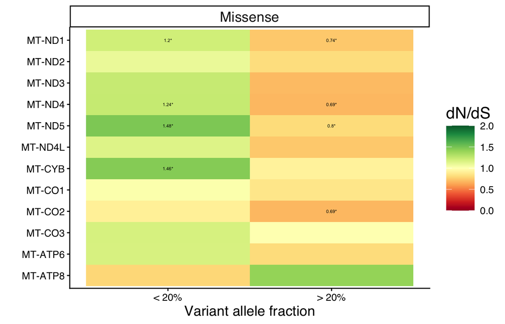

```r
selcv_res_by_dichotomous_vaf<-Map(dndsout=dndscv_by_dichotomous_vaf_blood,VAF_bin=new_VAF_groups,function(dndsout,VAF_bin) {
  temp<-dndsout$sel_cv%>%
    dplyr::select(gene_name,wmis_cv,wnon_cv,qmis_cv,qtrunc_cv)

  dplyr::bind_rows(temp%>%dplyr::select(gene_name,"dNdS"=wmis_cv,"qval"=qmis_cv)%>%mutate(type="Missense"),
                   temp%>%dplyr::select(gene_name,"dNdS"=wnon_cv,"qval"=qtrunc_cv)%>%mutate(type="Nonsense"))%>%
    mutate(VAF_group=VAF_bin)
})%>%dplyr::bind_rows()%>%
  mutate(VAF_group=factor(VAF_group,levels=VAF_groups$labels))

dnds_heatmap_by_dichotomous_vaf_by_gene<-selcv_res_by_dichotomous_vaf%>%
  mutate(dnds_if_signif=ifelse(qval<qval_cutoff,paste0(round(dNdS,2),"*"),""),
         gene_name=factor(gene_name,levels=rev(gene_order)))%>%
  filter(VAF_group%in%VAF_groups$labels[-1])%>%
  dplyr::filter(type=="Missense")%>%
  ggplot(aes(y=gene_name,x=VAF_group,fill=pmin(dNdS,2),label=dnds_if_signif))+
  geom_tile()+
  facet_grid(~type)+
  geom_text(aes(col=type),size=1.6)+
  scale_color_manual(values=c("black","white"),guide="none")+
  theme_classic()+
  my_markdown_theme+
  #theme(axis.text.x=element_text(angle=90))+
  scale_fill_gradientn(colors=RColorBrewer::brewer.pal(n=11,name = "RdYlGn"),limits=c(0,2))+
  labs(x="Variant allele fraction",y="",fill="dN/dS")

dnds_heatmap_by_dichotomous_vaf_by_gene
```

```r
save_plot(filename = paste0(plots_dir,"dnds_heatmap_by_dichotomous_vaf_by_gene.pdf"),dnds_heatmap_by_dichotomous_vaf_by_gene,width=2.2,height=2.5)
```

## Re-analysis of Ju et al, cancer data

```r
ju_dat<-readxl::read_excel(paste0(root_dir,"/data/elife-02935-supp2-v2.xlsx"))
```

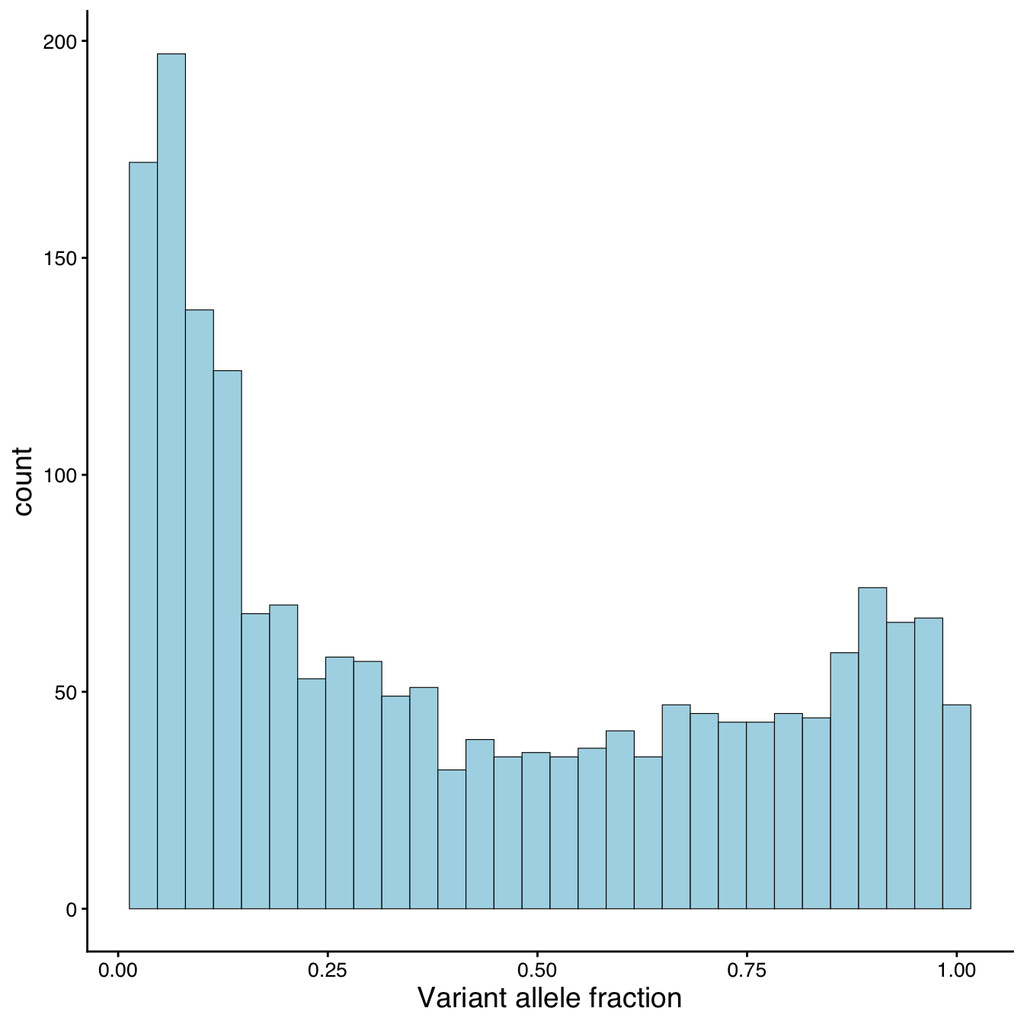

```r
ju_dat_reduced<-ju_dat%>%dplyr::select("sampleID"=Tumour_sampleID,
                                 "pos"=mtDNA_pos,
                                 "ref"=wt_allele,
                                 "alt"=var_allele,
                                 "vaf"=`VAF(T)`)%>%
  mutate("chr"="MT",.before="pos")

#Look at the heteroplasmy distribution
ju_vaf_distribution<-ju_dat_reduced%>%
  ggplot(aes(x=vaf))+
  geom_histogram(col="black",linewidth=0.2,fill="lightblue")+
  theme_classic()+
  my_markdown_theme+
  labs(x="Variant allele fraction")
ju_vaf_distribution
```

```r
save_plot(filename = paste0(plots_dir,"ju_vaf_distribution.pdf"),ju_vaf_distribution,width=2,height=2.5)
```

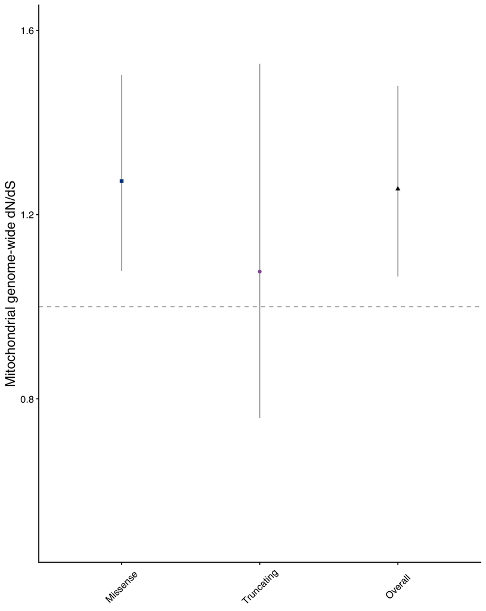

```r
dndsout<-dndscv(ju_dat_reduced,
       gene_list=all_mtDNA_genes,
       refdb = mtref_rda_path,
       numcode = 2,
       max_coding_muts_per_sample = Inf,
       max_muts_per_gene_per_sample = Inf)

get_dnds_pvalue <- function(globaldnds, term = "wmis") {
  mle    <- globaldnds[term, "mle"]
  cilow  <- globaldnds[term, "cilow"]
  cihigh <- globaldnds[term, "cihigh"]

  log_se <- (log(cihigh) - log(cilow)) / (2 * 1.96)
  z      <- log(mle) / log_se
  p      <- 2 * pnorm(-abs(z))

  return(data.frame(term = term, mle = mle,
                    cilow = cilow, cihigh = cihigh,
                    p_value = p))
}

# Apply to all terms
results <- do.call(rbind, lapply(
  c("wmis", "wnon", "wspl", "wtru", "wall"),
  function(t) get_dnds_pvalue(dndsout$globaldnds, t)
))

#Visualize results
max_dnds_value=1.6
stats_to_include=c("Missense","Truncating","Overall")
ju_global_dnds_plot<-dndsout$globaldnds%>%
  filter(!is.na(name) & complete.cases(.))%>%
  mutate(name=factor(rename_vec[name],levels=stats_to_include))%>%
  filter(name%in%stats_to_include)%>%
  ggplot(aes(x=name,y = mle, ymin = cilow, ymax = cihigh, color = name, shape = name)) +
  geom_linerange(position= position_dodge2(width=0.75), linewidth = 0.5, color="darkgrey") +
  geom_point(position=position_dodge2(width=0.75), size = 1.5)+
  labs(y = "Mitochondrial genome-wide dN/dS") +
  theme_classic() +
  ylim(c(0.5,max_dnds_value))+
  scale_color_manual(values = mut_type_cols, name="Mutation type") +
  scale_shape_manual(values = c(15, 16, 17, 18), name = "Mutation type") +
  geom_hline(yintercept=1, linetype='dashed', col = 'darkgrey', linewidth = 0.5) +
  my_markdown_theme+
  #facet_wrap(~tissue,nrow=1)+
  theme(axis.title.x=element_blank(),
        axis.text.x=element_text(angle=45,vjust = +0.5),
        legend.title=element_blank(),
        legend.position="none")
ju_global_dnds_plot
```

```r
save_plot(filename = paste0(plots_dir,"ju_global_dnds_plot.pdf"),ju_global_dnds_plot,width=2,height=2.5)
```

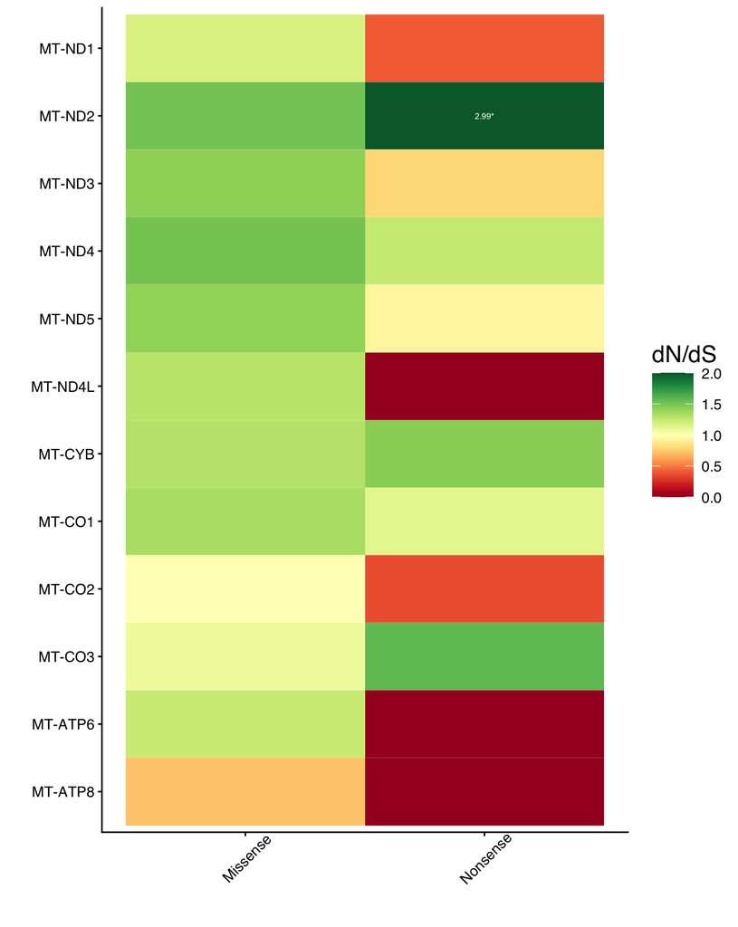

```r
temp<-dndsout$sel_cv%>%
  dplyr::select(gene_name,wmis_cv,wnon_cv,qmis_cv,qtrunc_cv)

qval_cutoff=0.05
ju_dnds_by_gene_heatmap<-dplyr::bind_rows(temp%>%dplyr::select(gene_name,"dNdS"=wmis_cv,"qval"=qmis_cv)%>%mutate(type="Missense"),
                 temp%>%dplyr::select(gene_name,"dNdS"=wnon_cv,"qval"=qtrunc_cv)%>%mutate(type="Nonsense"))%>%
  dplyr::filter(gene_name%in%target_genes)%>%
  mutate(dnds_if_signif=ifelse(qval<qval_cutoff,paste0(round(dNdS,2),"*"),""),
         gene_name=factor(gene_name,levels=rev(gene_order)))%>%
  ggplot(aes(y=gene_name,x=type,fill=pmin(dNdS,2),label=dnds_if_signif))+
  geom_tile()+
  geom_text(aes(col=type),size=2)+
  scale_color_manual(values=c("black","white"),guide="none")+
  theme_classic()+
  my_markdown_theme+
  theme(axis.text.x=element_text(angle=45,vjust=0.7))+
  scale_fill_gradientn(colors=RColorBrewer::brewer.pal(n=11,name = "RdYlGn"),limits=c(0,2))+
  labs(x="",y="",fill="dN/dS")
ju_dnds_by_gene_heatmap
```